# Data

Data compiled and used in this project includes behavioural data on grouping patterns and dominance, and well as DNA sequence data information.

# Setup

Load packages necessary for data proceessing.

```r
library(tidyverse)
library(ggplot2)
library(ggthemes)
library(ggforce)
library(ggridges)
library(ggsci)
library(wesanderson)
library(ggallin)
library(reshape2)
library(Matrix)
library(ggridges)
library(ggdark)
library(gghighlight)
```

set colour schemes

```r
two_colors <- c(wes_palette("Zissou1")[1], wes_palette("Zissou1")[4])

two_colors_reverse <- c(wes_palette("Zissou1")[4], wes_palette("Zissou1")[1])

three_colors <- c(wes_palette("BottleRocket2")[2], wes_palette("Zissou1")[2], wes_palette("Zissou1")[3])
```

# Behavioural data processing

## Grouping information

Group information is stored in *sequenced_samples_groups.csv*.

```r
sampleID_group_full <- read.csv("data/sequenced_samples_groups.csv", header = TRUE, sep = ";", as.is = TRUE)


str(sampleID_group_full)
```

```
'data.frame':   95 obs. of  4 variables:
 $ Group_ID       : chr  "wing_tags" "wing_tags" "wing_tags" "wing_tags" ...
 $ Sample.ind.code: chr  "A1295" "A1296" "A1297" "A1298" ...
 $ Real.ind.code  : chr  "W1295" "W1296" "W1297" "W1298" ...
 $ Colour_.bands  : chr  "WT002" "WT003" "WT004" "WT021" ...
```

```r
#rename Real.ind.code to ID
sampleID_group_full <- rename(sampleID_group_full, "ID" = "Sample.ind.code")

#only keep group and ID
sampleID_group <- select(sampleID_group_full, Group_ID, ID)
str(sampleID_group)
```

```
'data.frame':   95 obs. of  2 variables:
 $ Group_ID: chr  "wing_tags" "wing_tags" "wing_tags" "wing_tags" ...
 $ ID      : chr  "A1295" "A1296" "A1297" "A1298" ...
```

There are three samples that are not listed correctly and would lead to NA’s in downstream analysis, so we manually adjust them here

```r
#correct sample B1299 is missing
sample_info_add <- data.frame (Group_ID = c("wing_tags", "wing_tags", "5509"),
                               ID = c("B1299", "W1304", "W1345"))
sample_info_add
```

| Group_ID | ID |
| --- | --- |
| wing_tags | B1299 |
| wing_tags | W1304 |
| 5509 | W1345 |

```r
sampleID_group <- rbind(sampleID_group, sample_info_add)
```

## Breeding pair information

Information on breeding pairs in 2018 is stored in *breedingpairs_2018.csv*.

```r
pairs <- read.csv("data/breedingpairs_2018.csv", header = TRUE, sep = ";", as.is = TRUE)
str(pairs)
```

```
'data.frame':   22 obs. of  3 variables:
 $ Female: chr  "YOBK" "GOOP" "BWWK" "BYYO" ...
 $ Male  : chr  "WKOW" "KKRK" "WBKR" "KKRK" ...
 $ group : int  1 1 1 1 1 1 1 1 1 1 ...
```

Merge group and pairing information

```r
#add ID for females###########################################################

##rename Real.ind.code to ID
pairs <- rename(pairs, "Colour_.bands" = "Female")

pairs_ID <- left_join(pairs, sampleID_group_full, by = "Colour_.bands" )

pairs_ID <- rename(pairs_ID, "ID_Pair_F" = "ID")

##only keep group and ID
pairs_ID <- select(pairs_ID, Male, group, Group_ID, ID_Pair_F)


#add ID for males##############################################################

##rename Real.ind.code to ID
pairs_ID <- rename(pairs_ID, "Colour_.bands" = "Male")

pairs_ID <- left_join(pairs_ID, sampleID_group_full, by = "Colour_.bands" )

pairs_ID <- rename(pairs_ID, "ID_Pair_M" = "ID")

##only keep group and ID
pairs_ID <- select(pairs_ID, ID_Pair_F, ID_Pair_M)

#add column with concatenated pairs_ID to later match to relatedness table

pairs_ID$ID_Pair <- paste(pairs_ID$ID_Pair_F, pairs_ID$ID_Pair_M, sep ="-")

pairs_ID_2 <- pairs_ID
pairs_ID_2$ID_Pair <- paste(pairs_ID$ID_Pair_M, pairs_ID$ID_Pair_F, sep ="-")

pairs_ID <- bind_rows(pairs_ID, pairs_ID_2)


#add column specifying breeding pair
pairs_ID$breedingpair <- "breeding_pair"

#drop NAs
pairs_ID <- pairs_ID %>% drop_na()
str(pairs_ID)
```

```
'data.frame':   20 obs. of  4 variables:
 $ ID_Pair_F   : chr  "W1279" "W1287" "W1287" "W1294" ...
 $ ID_Pair_M   : chr  "W1272" "W1273" "W1272" "W1289" ...
 $ ID_Pair     : chr  "W1279-W1272" "W1287-W1273" "W1287-W1272" "W1294-W1289" ...
 $ breedingpair: chr  "breeding_pair" "breeding_pair" "breeding_pair" "breeding_pair" ...
```

## Sex information

Sex information is stored in *samples_sex.csv*. Sex was determined in the field and confirmed at least once with a molecular sexing method in the lab. For cases with mismatch between field and molecular sex we set the sex to undetermined. Field observations were updated in Sept. 2021 and corrected some previously misidentifications.

```r
sampleID_sex <- read.csv("data/samples_sex.csv", header = TRUE, sep = ";", as.is = TRUE)
str(sampleID_sex)
```

```
'data.frame':   133 obs. of  2 variables:
 $ ID : chr  "A1295" "A1296" "A1297" "A1298" ...
 $ sex: chr  "m" "f" "m" "m" ...
```

merge group and sex information

```r
sample_info <- full_join(sampleID_group, sampleID_sex, by = "ID")
str(sample_info)
```

```
'data.frame':   133 obs. of  3 variables:
 $ Group_ID: chr  "wing_tags" "wing_tags" "wing_tags" "wing_tags" ...
 $ ID      : chr  "A1295" "A1296" "A1297" "A1298" ...
 $ sex     : chr  "m" "f" "m" "m" ...
```

save sample overview

```r
save(sample_info, file = "data/sample_info.RData")
```

## Dominance information

Data on dominance hierarchies is available for three groups. Information on dominance hierarchy of the mpala group is stored in *mpala_ranks.csv*, for wing-tags in *wing_tags_ranks.csv*, for wt025 in *wt025_ranks*. We start with keeping the information seperate for each of the three groups.

```r
dominance_mpala <- read.csv("data/mpala_ranks.csv", header = TRUE, sep = ",", as.is = TRUE)
dominance_wingtags <- read.csv("data/wing_tags_ranks.csv", header = TRUE, sep = ",", as.is = TRUE)
dominance_wt025 <- read.csv("data/wt025_ranks.csv", header = TRUE, sep = ",", as.is = TRUE)

#combine dominance dataframes in one list
dominance <- list(dominance_mpala, dominance_wingtags, dominance_wt025)

#remove first column "X" in data frames
dominance <- lapply(dominance, "[", -1)

#rename column names in data frames to be consistent
dominance <- lapply(dominance, setNames, c("rank", "ID"))

#for each group, create dataframe with dominance differences between dyads

##create two ID columns based on IDs in group
dominance_groups <- c("mpala", "wingtags", "wt025") #define groups for which we have dominance data

dominance_adjacency <- list() #create an empty list

dominance_dyads <- list() #create an empty list

for (i in 1:length(dominance_groups)) {

  #create first column with IDs of group
  ID_1 <- dominance[[i]]$ID

  #create second column with IDs of group
  ID_2 <- dominance[[i]]$ID

  #bind two ID columns together
  dominance_adjacency[[i]] <- bind_cols(ID_1, ID_2)

  #name the two ID columns as ID_1 and ID_2
  names(dominance_adjacency[[i]]) <- c("ID_1", "ID_2")

  #generate all combinations of IDs
  dominance_dyads[[i]] <- tidyr::expand(dominance_adjacency[[i]], ID_1, ID_2)

  #remove all self dyads
  dominance_dyads[[i]] <- filter(dominance_dyads[[i]], ID_1 != ID_2)

  #add column with dominance rank of ID_1
  dominance_dyads[[i]] <- left_join(dominance_dyads[[i]], dominance[[i]], by = c("ID_1" = "ID"))

  #change column name of rank to rank_1
  dominance_dyads[[i]] <- rename(dominance_dyads[[i]], c(rank_1 = "rank"))

  #add column with dominance rank of ID_2
  dominance_dyads[[i]] <- left_join(dominance_dyads[[i]], dominance[[i]], by = c("ID_2" = "ID"))

  #change column name of rank to rank_2
  dominance_dyads[[i]] <- rename(dominance_dyads[[i]], c(rank_2 = "rank"))

  #add column with rank difference of dyads (take absolute value to not have negatives)
  dominance_dyads[[i]]$RankDiff <- abs(dominance_dyads[[i]]$rank_1 - dominance_dyads[[i]]$rank_2)

  #add column with dyad
  dominance_dyads[[i]]$dyad <- paste(dominance_dyads[[i]]$ID_1, dominance_dyads[[i]]$ID_2, sep = "-")

}
```

```
* NA -> ...1
* NA -> ...2
* NA -> ...1
* NA -> ...2
* NA -> ...1
* NA -> ...2
```

```r
str(dominance_dyads)
```

```
List of 3
 $ : tibble [600 x 6] (S3: tbl_df/tbl/data.frame)
  ..$ ID_1    : chr [1:600] "D4712" "D4712" "D4712" "D4712" ...
  ..$ ID_2    : chr [1:600] "D4713" "D4714" "D4715" "D4716" ...
  ..$ rank_1  : int [1:600] 15 15 15 15 15 15 15 15 15 15 ...
  ..$ rank_2  : int [1:600] 10 11 19 23 21 5 8 2 1 20 ...
  ..$ RankDiff: int [1:600] 5 4 4 8 6 10 7 13 14 5 ...
  ..$ dyad    : chr [1:600] "D4712-D4713" "D4712-D4714" "D4712-D4715" "D4712-D4716" ...
 $ : tibble [702 x 6] (S3: tbl_df/tbl/data.frame)
  ..$ ID_1    : chr [1:702] "W1295" "W1295" "W1295" "W1295" ...
  ..$ ID_2    : chr [1:702] "W1296" "W1297" "W1298" "W1299" ...
  ..$ rank_1  : int [1:702] 12 12 12 12 12 12 12 12 12 12 ...
  ..$ rank_2  : int [1:702] 26 7 13 21 5 9 14 10 15 17 ...
  ..$ RankDiff: int [1:702] 14 5 1 9 7 3 2 2 3 5 ...
  ..$ dyad    : chr [1:702] "W1295-W1296" "W1295-W1297" "W1295-W1298" "W1295-W1299" ...
 $ : tibble [702 x 6] (S3: tbl_df/tbl/data.frame)
  ..$ ID_1    : chr [1:702] "W1318" "W1318" "W1318" "W1318" ...
  ..$ ID_2    : chr [1:702] "W1319" "W1320" "W1322" "W1323" ...
  ..$ rank_1  : int [1:702] 16 16 16 16 16 16 16 16 16 16 ...
  ..$ rank_2  : int [1:702] 20 13 9 1 17 15 12 23 19 10 ...
  ..$ RankDiff: int [1:702] 4 3 7 15 1 1 4 7 3 6 ...
  ..$ dyad    : chr [1:702] "W1318-W1319" "W1318-W1320" "W1318-W1322" "W1318-W1323" ...
```

save dominance info

```r
save(dominance_dyads, file = "data/dominance_info.RData")
```

# Sequencing data processing

First, we load an overview of the analysed sequencing libraries. They are stored in the folder `pipeline` as *file_list.tsv*.

```r
seqlib_overview <- read.delim("data/pipeline/file_list.tsv", header = TRUE,  as.is = TRUE)
str(seqlib_overview)
```

```
'data.frame':   238 obs. of  6 variables:
 $ file_name: chr  "mpg_L16936-1_W1350_S1_R1_001.fastq.gz" "mpg_L16936-1_W1350_S1_R2_001.fastq.gz" "mpg_L16926-1_W1398_S2_R1_001.fastq.gz" "mpg_L16926-1_W1398_S2_R2_001.fastq.gz" ...
 $ RGID     : int  1 1 1 1 1 1 1 1 1 1 ...
 $ RGLB     : chr  "lib1" "lib1" "lib1" "lib1" ...
 $ RGPL     : chr  "ILLUMINA" "ILLUMINA" "ILLUMINA" "ILLUMINA" ...
 $ RGPU     : chr  "unit1" "unit1" "unit1" "unit1" ...
 $ RGSM     : chr  "RGID1_S1" "RGID1_S1" "RGID1_S2" "RGID1_S2" ...
```

The information about the sampled individual, which we will later need to assign the relatedness estimation to specific individuals, is available in the *file_name* column. We will extract this information and put it in an extra *ID* column.

```r
#first need to create a new column that includes the sample ID
seqlib_overview$ID <- gsub("([[:alnum:]]{3}_[[:alnum:]]{6}-[[:digit:]])_([[:alnum:]]{5,7})_([[:alnum:]]{2,3}_[[:alnum:]]{2}_[[:graph:]]{12})", "\\2", seqlib_overview$file_name)

str(seqlib_overview)
```

```
'data.frame':   238 obs. of  7 variables:
 $ file_name: chr  "mpg_L16936-1_W1350_S1_R1_001.fastq.gz" "mpg_L16936-1_W1350_S1_R2_001.fastq.gz" "mpg_L16926-1_W1398_S2_R1_001.fastq.gz" "mpg_L16926-1_W1398_S2_R2_001.fastq.gz" ...
 $ RGID     : int  1 1 1 1 1 1 1 1 1 1 ...
 $ RGLB     : chr  "lib1" "lib1" "lib1" "lib1" ...
 $ RGPL     : chr  "ILLUMINA" "ILLUMINA" "ILLUMINA" "ILLUMINA" ...
 $ RGPU     : chr  "unit1" "unit1" "unit1" "unit1" ...
 $ RGSM     : chr  "RGID1_S1" "RGID1_S1" "RGID1_S2" "RGID1_S2" ...
 $ ID       : chr  "W1350" "W1350" "W1398" "W1398" ...
```

Next, we evaluate the quality of the data and the different sequencing approaches. An overview of the data as output from the Nextflow pipeline as of 29th July 2021 is stored in *preprocessing_overview.tsv*

```r
data_overview <- read.delim("data/pipeline/preprocessing_overview.tsv", as.is = TRUE)
str(data_overview)
```

```
'data.frame':   119 obs. of  31 variables:
 $ RGSM                                     : chr  "RGID1_S1" "RGID1_S2" "RGID1_S3" "RGID1_S4" ...
 $ RGID                                     : int  1 1 1 1 1 1 1 1 1 1 ...
 $ RGLB                                     : chr  "lib1" "lib1" "lib1" "lib1" ...
 $ RGPL                                     : chr  "ILLUMINA" "ILLUMINA" "ILLUMINA" "ILLUMINA" ...
 $ RGPU                                     : chr  "unit1" "unit1" "unit1" "unit1" ...
 $ filename_one                             : chr  "mpg_L16936-1_W1350_S1_R1_001.fastq.gz" "mpg_L16926-1_W1398_S2_R1_001.fastq.gz" "mpg_L16927-1_W1429_S3_R1_001.fastq.gz" "mpg_L16928-1_W1502_S4_R1_001.fastq.gz" ...
 $ filename_two                             : chr  "mpg_L16936-1_W1350_S1_R2_001.fastq.gz" "mpg_L16926-1_W1398_S2_R2_001.fastq.gz" "mpg_L16927-1_W1429_S3_R2_001.fastq.gz" "mpg_L16928-1_W1502_S4_R2_001.fastq.gz" ...
 $ reads_pre_trim_one                       : int  3844063 3360132 3034920 6695288 6040662 2842383 3879834 6087445 5686616 4107154 ...
 $ reads_pre_trim_two                       : int  3844063 3360132 3034920 6695288 6040662 2842383 3879834 6087445 5686616 4107154 ...
 $ reads_pre_trim_total                     : int  7688126 6720264 6069840 13390576 12081324 5684766 7759668 12174890 11373232 8214308 ...
 $ reads_post_trim_one                      : int  3334957 3057420 2775271 6144973 5496263 2618095 3544978 5592586 5206646 3740830 ...
 $ reads_post_trim_two                      : int  3317567 2622060 2444309 5472149 4763684 2298940 2933104 4916336 4551423 3252219 ...
 $ reads_post_trim_total                    : int  6652524 5679480 5219580 11617122 10259947 4917035 6478082 10508922 9758069 6993049 ...
 $ reads_trimmed_lost_one                   : int  509106 302712 259649 550315 544399 224288 334856 494859 479970 366324 ...
```

[output cut: 17 more lines]

One sequencing library was resequenced in an additionl run but wrongly assigned to RGID 1, so we correct this

```r
data_overview$RGID[data_overview$filename_one == "mpg_L16936-1_W1350_S1_R1_001.fastq.gz"] <- "2"
```

```r
#create new column that specifies if sequencing results are from original run or from resequencing
data_overview <- data_overview %>%
  mutate(original_reseq = case_when(RGID == "1" ~ "original",
                                RGID == "2" ~ "reseq"))
```

```r
#first need to create a new column that includes the sample ID
data_overview$ID <- gsub("([[:alnum:]]{3}_[[:alnum:]]{6}-[[:digit:]])_([[:alnum:]]{5,7})_([[:alnum:]]{2,3}_[[:alnum:]]{2}_[[:graph:]]{12})", "\\2", data_overview$filename_one)

str(data_overview)
```

```
'data.frame':   119 obs. of  33 variables:
 $ RGSM                                     : chr  "RGID1_S1" "RGID1_S2" "RGID1_S3" "RGID1_S4" ...
 $ RGID                                     : chr  "2" "1" "1" "1" ...
 $ RGLB                                     : chr  "lib1" "lib1" "lib1" "lib1" ...
 $ RGPL                                     : chr  "ILLUMINA" "ILLUMINA" "ILLUMINA" "ILLUMINA" ...
 $ RGPU                                     : chr  "unit1" "unit1" "unit1" "unit1" ...
 $ filename_one                             : chr  "mpg_L16936-1_W1350_S1_R1_001.fastq.gz" "mpg_L16926-1_W1398_S2_R1_001.fastq.gz" "mpg_L16927-1_W1429_S3_R1_001.fastq.gz" "mpg_L16928-1_W1502_S4_R1_001.fastq.gz" ...
 $ filename_two                             : chr  "mpg_L16936-1_W1350_S1_R2_001.fastq.gz" "mpg_L16926-1_W1398_S2_R2_001.fastq.gz" "mpg_L16927-1_W1429_S3_R2_001.fastq.gz" "mpg_L16928-1_W1502_S4_R2_001.fastq.gz" ...
 $ reads_pre_trim_one                       : int  3844063 3360132 3034920 6695288 6040662 2842383 3879834 6087445 5686616 4107154 ...
 $ reads_pre_trim_two                       : int  3844063 3360132 3034920 6695288 6040662 2842383 3879834 6087445 5686616 4107154 ...
 $ reads_pre_trim_total                     : int  7688126 6720264 6069840 13390576 12081324 5684766 7759668 12174890 11373232 8214308 ...
 $ reads_post_trim_one                      : int  3334957 3057420 2775271 6144973 5496263 2618095 3544978 5592586 5206646 3740830 ...
 $ reads_post_trim_two                      : int  3317567 2622060 2444309 5472149 4763684 2298940 2933104 4916336 4551423 3252219 ...
 $ reads_post_trim_total                    : int  6652524 5679480 5219580 11617122 10259947 4917035 6478082 10508922 9758069 6993049 ...
 $ reads_trimmed_lost_one                   : int  509106 302712 259649 550315 544399 224288 334856 494859 479970 366324 ...
```

[output cut: 19 more lines]

save data overview

```r
save(data_overview, file = "data/data_overview.RData")
```

## Sequencing data statistics

Calculate total and mean number of raw reads !!paired-end sequencing, so need to account for that

```r
total_raw_reads <- sum(data_overview$reads_pre_trim_total)
total_raw_reads
```

```
[1] 1393934732
```

```r
mean_raw_reads <- mean(data_overview$reads_pre_trim_total)
mean_raw_reads
```

```
[1] 11713737
```

```r
sd_raw_reads <- sd(data_overview$reads_pre_trim_total)
sd_raw_reads
```

```
[1] 5979400
```

Calculate total and mean number of quality filtered reads

```r
total_filtered_reads <- sum(data_overview$reads_post_trim_total)
total_filtered_reads
```

```
[1] 1218247416
```

```r
percent_filtered_reads <- total_filtered_reads/total_raw_reads
percent_filtered_reads
```

```
[1] 0.873963
```

```r
mean_filtered_reads <- mean(data_overview$reads_post_trim_total)
mean_filtered_reads
```

```
[1] 10237373
```

```r
percent_mean_filtered_reads <- mean_filtered_reads/mean_raw_reads
percent_mean_filtered_reads
```

```
[1] 0.873963
```

```r
sd_filtered_reads <- sd(data_overview$reads_post_trim_total)
sd_filtered_reads
```

```
[1] 5426886
```

```r
median_Trimmomatic_dropped <- median(data_overview$reads_trimmed_lost_total, na.rm = TRUE)
median_Trimmomatic_dropped
```

```
[1] 1310301
```

```r
IQR_Trimmomatic_dropped <- IQR(data_overview$reads_trimmed_lost_total, na.rm = TRUE)
IQR_Trimmomatic_dropped
```

```
[1] 749127
```

```r
range_Trimmomatic_dropped <- range(data_overview$reads_trimmed_lost_total, na.rm = TRUE)
range_Trimmomatic_dropped
```

```
[1]  323232 4158669
```

Calculate mapped reads

```r
median_mapped_reads <- median(data_overview$reads_mapped)
median_mapped_reads
```

```
[1] 9498515
```

```r
IQR_mapped_reads <- IQR(data_overview$reads_mapped)
IQR_mapped_reads
```

```
[1] 6902176
```

```r
range_mapped_reads <- range(data_overview$reads_mapped)
range_mapped_reads
```

```
[1]  1843218 32346499
```

Calculate duplicates

```r
median_duplicates <- median(data_overview$percent_duplication)
median_duplicates
```

```
[1] 0.056526
```

```r
range_duplicates <- range(data_overview$percent_duplication)
range_duplicates
```

```
[1] 0.039762 0.100763
```

Calculate final coverage

```r
median_final_coverage <- median(data_overview$average_coverage)
median_final_coverage
```

```
[1] 1.91596
```

```r
IQR_final_coverage <- IQR(data_overview$average_coverage)
IQR_final_coverage
```

```
[1] 0.601805
```

```r
range_final_coverage <- range(data_overview$average_coverage)
range_final_coverage
```

```
[1] 1.33748 4.31431
```

For the sequencing success, we compare the reads that passed Quality control (FastCQ and Trimmotaic) depending on original run (RGID = 1) and resequencing (RGID = 2).

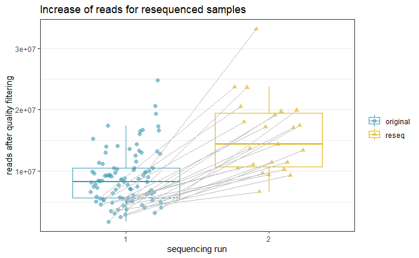

```r
theme_set(theme_bw()) #set theme to black and white

#theme_set(dark_theme_bw()) #set theme to black background for presentations

#compare reads (y-axis) between original vs. resequenced (x-axis, sorted to have original first) and color according to library prep (shotgun vs. capture)
ggplot(data_overview, aes(x = factor(RGID, level = c("1", "2")), y = reads_post_trim_total, color = original_reseq, shape = original_reseq)) +

   scale_colour_manual(values = two_colors, na.value = 1) +

  geom_point(size = 2, alpha = 0.6, aes(group = ID), position = position_dodge(0.5)) + #make points, transparent, and group samples

  geom_boxplot(alpha = 0, outlier.shape = NA) + #add boxplots but do not show them in legend

  #geom_violin(alpha = 0.5) + #or add violin plots


  geom_line(aes(group = ID), color = "grey", position = position_dodge(0.5), show.legend = FALSE) + #add line to connect samples present in both sequencing runs

  #stat_summary(fun = median, geom = "point", size = 5, alpha = 0.3, position = position_dodge(0.5)) +

  labs(x = "sequencing run", y = "reads after quality filtering") + #adjust axis labels


  theme(legend.title = element_blank()) + #remove legend title

  theme(panel.grid.major.x = element_blank()) + #remove x-axis grid lines


  ggtitle("Increase of reads for resequenced samples")
```

```r
NA
```

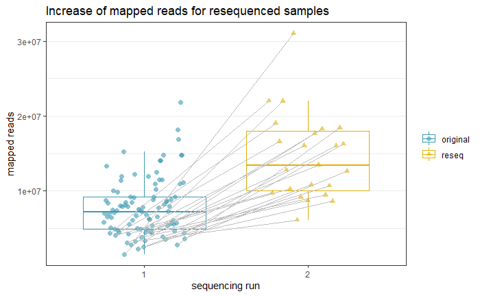

```r
#compare mapped reads (y-axis) between sequencing (x-axis, sorted to have original first) and color according to sequencing run
ggplot(data_overview, aes(x = factor(RGID, level = c("1", "2")), y = reads_mapped_and_paired, color = original_reseq, shape = original_reseq)) +

  scale_colour_manual(values = two_colors, na.value = 1)  +

  geom_point(size = 2, alpha = 0.6, aes(group = ID), position = position_dodge(0.5)) + #make points, transparent, and group samples

  geom_boxplot(alpha = 0, outlier.shape = NA) + #add boxplots but do not show them in legend

  #geom_violin(alpha = 0.5) + #or add violin plots


  geom_line(aes(group = ID), color = "grey", position = position_dodge(0.5), show.legend = FALSE) + #add line to connect samples present in both sequencing approaches

  #stat_summary(fun = median, geom = "point", size = 5, alpha = 0.3, position = position_dodge(0.5)) +

  labs(x = "sequencing run", y = "mapped reads") + #adjust axis labels


  theme(legend.title = element_blank()) + #remove legend title

  theme(panel.grid.major.x = element_blank()) + #remove x-axis grid lines


  ggtitle("Increase of mapped reads for resequenced samples")
```

```r
NA
```

Finally, let’s have a look at the coverage

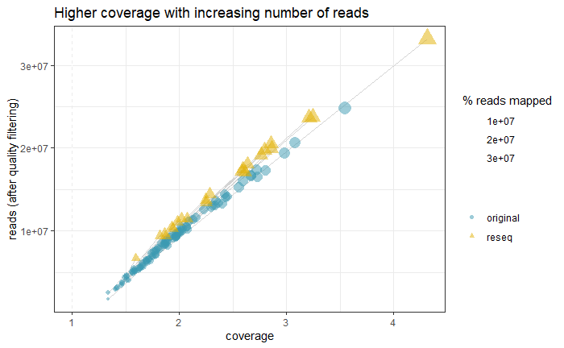

```r
#relate number of reads (y-axis) to final coverage (x-axis), color according to sequencing run (original vs. resequenced) and sample type, shape according to original run or resequencing
ggplot(data_overview, aes(x = average_coverage, y = reads_post_trim_total, color = original_reseq, shape = original_reseq)) +

  scale_colour_manual(values = two_colors, na.value = 1) +

  geom_line(aes(group = ID), color = "lightgrey", show.legend = FALSE) + #connect same samples

  geom_point(alpha = 0.5, aes(size = reads_mapped_and_paired, group = ID)) + #add points with slight transparency

  geom_vline(xintercept = 1, linetype = "dashed") + #include vertical line to show coverage cutoff

    #scale_y_log10(breaks = scales::trans_breaks("log10", function(x) 10^x), labels = scales::trans_format("log10", scales::math_format(10^.x))) + #make y-axis logarithmic

  #scale_x_log10() + #make x-axis logarithmic

  #annotation_logticks() +

  labs(x = "coverage", y = "reads (after quality filtering)",
       size = "% reads mapped", color ="", shape = "") +

  ggtitle("Higher coverage with increasing number of reads")
```

```r
NA
```

C-Curve

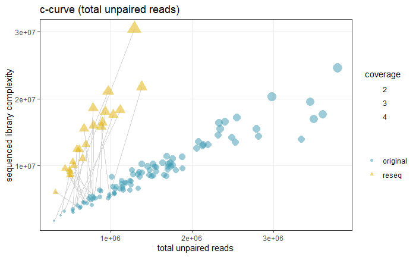

```r
#relate number of distinct reads (y-axis) to total reads (x-axis), color and shape according to original run or resequencing
ggplot(data_overview, aes(x = unpaired_reads_examined_for_deduplication, y = sequenced_library_complexity, color = original_reseq, shape = original_reseq)) +

  geom_line(aes(group = ID), color = "lightgrey", show.legend = FALSE) + #connect same samples

  geom_point(alpha = 0.5, aes(size = average_coverage, group = ID)) + #add points with slight transparency

  theme(panel.grid.minor.x = element_blank(), panel.grid.minor.y = element_blank()) + #remove x/y-axis grid lines

  labs(x = "total unpaired reads", y = "sequenced library complexity",
       size = "coverage", color ="", shape = "") + #adjust axis and legend labels

   scale_colour_manual(values = two_colors, na.value = 1) +

  ggtitle("c-curve (total unpaired reads)")
```

```r
NA
```

comparison to total surviving reads from Trimmomatic to distinct mapped reads

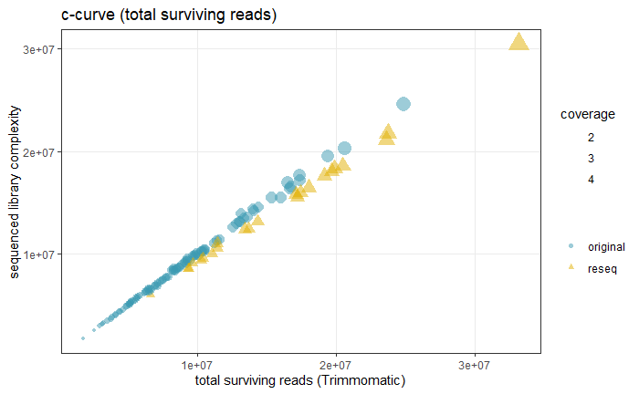

```r
#relate number of distinct reads (y-axis) to total surviving reads (x-axis), color  and sample type, shape according to original run or resequencing
ggplot(data_overview, aes(x =  reads_post_trim_total, y = sequenced_library_complexity, color = original_reseq, shape = original_reseq)) +

  scale_colour_manual(values = two_colors) +

  geom_point(alpha = 0.5, aes(size = average_coverage, group = ID)) + #add points with slight transparency

  theme(panel.grid.minor.x = element_blank(), panel.grid.minor.y = element_blank()) + #remove x/y-axis grid lines

  labs(x = "total surviving reads (Trimmomatic)", y = "sequenced library complexity",
       size = "coverage", color ="", shape = "") +  #adjust axis and legend labels

  ggtitle("c-curve (total surviving reads)")
```

```r
NA
NA
NA
```

plot overview of sequence data processing steps with a ridge plot

```r
reads_overview <- select(data_overview, ID, reads_pre_trim_total, reads_post_trim_total, reads_mapped, reads_mapped_and_paired, paired_reads_examined_for_deduplication, paired_read_duplicates, original_reseq)

#create column with nonduplicates
reads_overview <- mutate(reads_overview, nonduplicates = 2*(paired_reads_examined_for_deduplication -  paired_read_duplicates))

names(reads_overview) <-  c("ID", "raw", "filtered", "mapped", "mapped & paired", "paired examined", "paired duplicates", "original_reseq", "2 * paired non-duplicates")

#reorganize data to have all read information in singel column
reads_overview <- gather(reads_overview, "raw", "filtered", "mapped", "mapped & paired", "2 * paired non-duplicates", key = "processing_step", value = "reads")

reads_overview <- mutate(reads_overview, mio_reads = reads/1000000)

reads_overview$processing_step <- as.factor(reads_overview$processing_step)

str(reads_overview)
```

```
'data.frame':   595 obs. of  7 variables:
 $ ID               : chr  "W1350" "W1398" "W1429" "W1502" ...
 $ paired examined  : int  3094003 2475793 2291351 5174753 4449902 2167892 2782428 4657453 4288831 3054109 ...
 $ paired duplicates: int  221442 119369 103005 260460 197926 115543 120104 206962 194659 133521 ...
 $ original_reseq   : chr  "reseq" "original" "original" "original" ...
 $ processing_step  : Factor w/ 5 levels "2 * paired non-duplicates",..: 5 5 5 5 5 5 5 5 5 5 ...
 $ reads            : num  7688126 6720264 6069840 13390576 12081324 ...
 $ mio_reads        : num  7.69 6.72 6.07 13.39 12.08 ...
```

```
`guides(<scale> = FALSE)` is deprecated. Please use `guides(<scale> = "none")` instead.
```

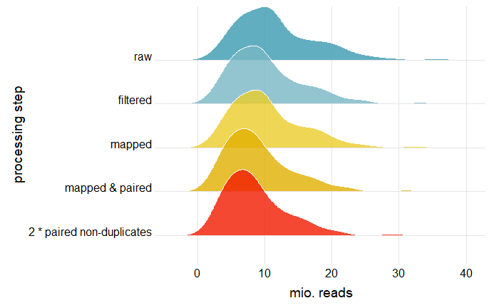

```r
#step_color <- c("#440154FF", "#5DC863FF", "#21908CFF", "#3B528BFF","#FDE725FF")

Five_colors <- c(wes_palette("Zissou1")[5], wes_palette("Zissou1")[2], wes_palette("Zissou1")[3], wes_palette("Zissou1")[4], wes_palette("Zissou1")[1])

ggplot(reads_overview, aes(x = mio_reads, y = fct_reorder(processing_step, reads, .fun = "max"), fill = processing_step)) +

   geom_density_ridges(alpha = 0.8, color = "white", scale = 1.5, rel_min_height = 0.01) +

  scale_fill_cyclical(values = Five_colors) +

  labs (x = "mio. reads", y = "processing step") +

  guides(fill = FALSE) +

  theme_ridges(center = TRUE) #+
```

```r
  #dark_theme_classic()
```

plot coverage and st.dv.

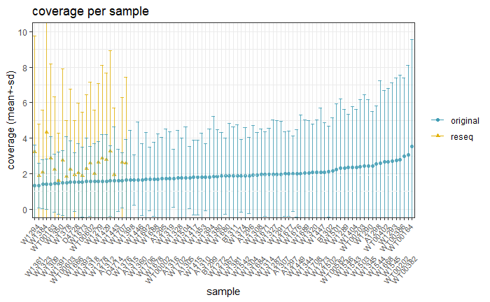

```r
#plot coverage (y-axis) including st.dev for every sample (x-axis), color according to original run or resequencing
ggplot(filter(data_overview, original_reseq == "original"), aes(x = reorder(ID, average_coverage), y = average_coverage, color = original_reseq, shape = original_reseq)) +

  scale_colour_manual(values = two_colors) +

  geom_point(aes(y=average_coverage), alpha = 0.8) +

  geom_point(data = filter(data_overview, original_reseq == "reseq"), aes(y=average_coverage), alpha = 0.8) +

  geom_errorbar(data = filter(data_overview, original_reseq == "reseq"), aes(ymin = average_coverage - average_coverarge_stdev, ymax = average_coverage + average_coverarge_stdev), alpha = 0.8) +

  geom_errorbar(aes(ymin = average_coverage - average_coverarge_stdev, ymax = average_coverage + average_coverarge_stdev), alpha = 0.8) +

  geom_hline(yintercept = 1, linetype = "dashed") + #include horizontal line to show coverage cutoff at 1X

  geom_hline(yintercept = median_final_coverage, linetype = "dotted") +

  coord_cartesian(ylim = c(0, 10)) + #adjust y axis

  scale_y_continuous(breaks = c(0, 2, 4, 6, 8, 10)) +

  labs(x = "sample", y = "coverage (mean+-sd)",
       color ="", shape = "") + #adjust axis and legend labels

  theme(axis.text.x = element_text(angle = 50, vjust = 1, hjust = 1, size = 8)) +

  scale_x_discrete(guide = guide_axis(n.dodge=2)) +  #avoid overlap of x-axis labels

  ggtitle("coverage per sample")
```

```r
NA
NA
```

## Sequencing data mapped to Gallus gallus

To evaluate whether the reference genome has an impact on downstream results, we also mapped the sequencing reads to the *Gallus gallus* genome.

```r
data_overview_Gg <- read.delim("data/pipeline/Ref_Ggallus/ggallus_preprocessing_overview.tsv", as.is = TRUE)
str(data_overview_Gg)
```

```
'data.frame':   119 obs. of  31 variables:
 $ RGSM                                     : chr  "RGID3_S1" "RGID1_S2" "RGID1_S3" "RGID1_S4" ...
 $ RGID                                     : int  3 1 1 1 1 1 1 1 1 1 ...
 $ RGLB                                     : chr  "lib3" "lib1" "lib1" "lib1" ...
 $ RGPL                                     : chr  "ILLUMINA" "ILLUMINA" "ILLUMINA" "ILLUMINA" ...
 $ RGPU                                     : chr  "unit1" "unit1" "unit1" "unit1" ...
 $ filename_one                             : chr  "mpg_L16936-1_W1350_S1_R1_001.fastq.gz" "mpg_L16926-1_W1398_S2_R1_001.fastq.gz" "mpg_L16927-1_W1429_S3_R1_001.fastq.gz" "mpg_L16928-1_W1502_S4_R1_001.fastq.gz" ...
 $ filename_two                             : chr  "mpg_L16936-1_W1350_S1_R2_001.fastq.gz" "mpg_L16926-1_W1398_S2_R2_001.fastq.gz" "mpg_L16927-1_W1429_S3_R2_001.fastq.gz" "mpg_L16928-1_W1502_S4_R2_001.fastq.gz" ...
 $ reads_pre_trim_one                       : int  3844063 3360132 3034920 6695288 6040662 2842383 3879834 6087445 5686616 4107154 ...
 $ reads_pre_trim_two                       : int  3844063 3360132 3034920 6695288 6040662 2842383 3879834 6087445 5686616 4107154 ...
 $ reads_pre_trim_total                     : int  7688126 6720264 6069840 13390576 12081324 5684766 7759668 12174890 11373232 8214308 ...
 $ reads_post_trim_one                      : int  3333674 3056730 2774880 6143750 5495243 2617445 3544350 5591764 5205423 3740024 ...
 $ reads_post_trim_two                      : int  3301938 2613160 2436306 5450969 4743787 2291962 2922549 4903346 4537414 3241632 ...
 $ reads_post_trim_total                    : int  6635612 5669890 5211186 11594719 10239030 4909407 6466899 10495110 9742837 6981656 ...
 $ reads_trimmed_lost_one                   : int  510389 303402 260040 551538 545419 224938 335484 495681 481193 367130 ...
```

[output cut: 17 more lines]

```r
data_overview_Gg$RGID[data_overview_Gg$filename_one == "mpg_L16936-1_W1350_S1_R1_001.fastq.gz"] <- "2"
```

```r
#create new column that specifies if sequencing results are from original run or from resequencing
data_overview_Gg <- data_overview_Gg %>%
  mutate(original_reseq = case_when(RGID == "1" ~ "original",
                                RGID == "2" ~ "reseq"))
```

```r
#first need to create a new column that includes the sample ID
data_overview_Gg$ID <- gsub("([[:alnum:]]{3}_[[:alnum:]]{6}-[[:digit:]])_([[:alnum:]]{5,7})_([[:alnum:]]{2,3}_[[:alnum:]]{2}_[[:graph:]]{12})", "\\2", data_overview_Gg$filename_one)

str(data_overview_Gg)
```

```
'data.frame':   119 obs. of  33 variables:
 $ RGSM                                     : chr  "RGID3_S1" "RGID1_S2" "RGID1_S3" "RGID1_S4" ...
 $ RGID                                     : chr  "2" "1" "1" "1" ...
 $ RGLB                                     : chr  "lib3" "lib1" "lib1" "lib1" ...
 $ RGPL                                     : chr  "ILLUMINA" "ILLUMINA" "ILLUMINA" "ILLUMINA" ...
 $ RGPU                                     : chr  "unit1" "unit1" "unit1" "unit1" ...
 $ filename_one                             : chr  "mpg_L16936-1_W1350_S1_R1_001.fastq.gz" "mpg_L16926-1_W1398_S2_R1_001.fastq.gz" "mpg_L16927-1_W1429_S3_R1_001.fastq.gz" "mpg_L16928-1_W1502_S4_R1_001.fastq.gz" ...
 $ filename_two                             : chr  "mpg_L16936-1_W1350_S1_R2_001.fastq.gz" "mpg_L16926-1_W1398_S2_R2_001.fastq.gz" "mpg_L16927-1_W1429_S3_R2_001.fastq.gz" "mpg_L16928-1_W1502_S4_R2_001.fastq.gz" ...
 $ reads_pre_trim_one                       : int  3844063 3360132 3034920 6695288 6040662 2842383 3879834 6087445 5686616 4107154 ...
 $ reads_pre_trim_two                       : int  3844063 3360132 3034920 6695288 6040662 2842383 3879834 6087445 5686616 4107154 ...
 $ reads_pre_trim_total                     : int  7688126 6720264 6069840 13390576 12081324 5684766 7759668 12174890 11373232 8214308 ...
 $ reads_post_trim_one                      : int  3333674 3056730 2774880 6143750 5495243 2617445 3544350 5591764 5205423 3740024 ...
 $ reads_post_trim_two                      : int  3301938 2613160 2436306 5450969 4743787 2291962 2922549 4903346 4537414 3241632 ...
 $ reads_post_trim_total                    : int  6635612 5669890 5211186 11594719 10239030 4909407 6466899 10495110 9742837 6981656 ...
 $ reads_trimmed_lost_one                   : int  510389 303402 260040 551538 545419 224938 335484 495681 481193 367130 ...
```

[output cut: 19 more lines]

save data overview

```r
save(data_overview_Gg, file = "data/data_overview_Gg.RData")
```

### Sequencing data mapped to G. gallus statistics

Calculate total and mean number of raw reads (same as above) !!paired-end sequencing, so need to account for that

```r
total_raw_reads <- sum(data_overview_Gg$reads_pre_trim_total)
total_raw_reads
```

```
[1] 1393934732
```

```r
mean_raw_reads <- mean(data_overview_Gg$reads_pre_trim_total)
mean_raw_reads
```

```
[1] 11713737
```

```r
sd_raw_reads <- sd(data_overview_Gg$reads_pre_trim_total)
sd_raw_reads
```

```
[1] 5979400
```

```r
total_filtered_reads <- sum(data_overview_Gg$reads_post_trim_total)
total_filtered_reads
```

```
[1] 1213192664
```

```r
percent_filtered_reads <- total_filtered_reads/total_raw_reads
percent_filtered_reads
```

```
[1] 0.8703368
```

```r
mean_filtered_reads <- mean(data_overview_Gg$reads_post_trim_total)
mean_filtered_reads
```

```
[1] 10194896
```

```r
percent_mean_filtered_reads <- mean_filtered_reads/mean_raw_reads
percent_mean_filtered_reads
```

```
[1] 0.8703368
```

```r
sd_filtered_reads <- sd(data_overview_Gg$reads_post_trim_total)
sd_filtered_reads
```

```
[1] 5357774
```

```r
median_Trimmomatic_dropped <- median(data_overview_Gg$reads_trimmed_lost_total, na.rm = TRUE)
median_Trimmomatic_dropped
```

```
[1] 1314024
```

```r
IQR_Trimmomatic_dropped <- IQR(data_overview_Gg$reads_trimmed_lost_total, na.rm = TRUE)
IQR_Trimmomatic_dropped
```

```
[1] 806676
```

```r
range_Trimmomatic_dropped <- range(data_overview_Gg$reads_trimmed_lost_total, na.rm = TRUE)
range_Trimmomatic_dropped
```

```
[1]  326632 4204805
```

Calculate mapped reads

```r
median_mapped_reads_Gg <- median(data_overview_Gg$reads_mapped)
median_mapped_reads_Gg
```

```
[1] 8122764
```

```r
IQR_mapped_reads_Gg <- IQR(data_overview_Gg$reads_mapped)
IQR_mapped_reads_Gg
```

```
[1] 5941942
```

```r
range_mapped_reads_Gg <- range(data_overview_Gg$reads_mapped)
range_mapped_reads_Gg
```

```
[1]  1550386 29699669
```

Calculate duplicates

```r
median_duplicates_Gg <- median(data_overview_Gg$percent_duplication)
median_duplicates_Gg
```

```
[1] 0.049953
```

```r
range_duplicates_Gg <- range(data_overview_Gg$percent_duplication)
range_duplicates_Gg
```

```
[1] 0.035229 0.093921
```

Calculate final coverage

```r
median_final_coverage_Gg <- median(data_overview_Gg$average_coverage)
median_final_coverage_Gg
```

```
[1] 0.84884
```

```r
IQR_final_coverage_Gg <- IQR(data_overview_Gg$average_coverage)
IQR_final_coverage_Gg
```

```
[1] 0.622564
```

```r
range_final_coverage_Gg <- range(data_overview_Gg$average_coverage)
range_final_coverage_Gg
```

```
[1] 0.161309 3.094590
```

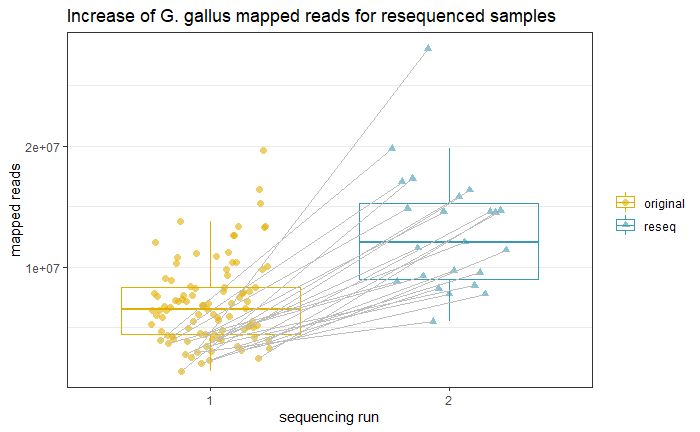

```r
#compare mapped reads (y-axis) between sequencing (x-axis, sorted to have original first) and color according to sequencing run
ggplot(data_overview_Gg, aes(x = factor(RGID, level = c("1", "2")), y = reads_mapped_and_paired, color = original_reseq, shape = original_reseq)) +

  scale_colour_manual(values = two_colors_reverse, na.value = 1)  +

  geom_point(size = 2, alpha = 0.6, aes(group = ID), position = position_dodge(0.5)) + #make points, transparent, and group samples

  geom_boxplot(alpha = 0, outlier.shape = NA) + #add boxplots but do not show them in legend

  #geom_violin(alpha = 0.5) + #or add violin plots


  geom_line(aes(group = ID), color = "grey", position = position_dodge(0.5), show.legend = FALSE) + #add line to connect samples present in both sequencing approaches

  #stat_summary(fun = median, geom = "point", size = 5, alpha = 0.3, position = position_dodge(0.5)) +

  labs(x = "sequencing run", y = "mapped reads") + #adjust axis labels


  theme(legend.title = element_blank()) + #remove legend title

  theme(panel.grid.major.x = element_blank()) + #remove x-axis grid lines


  ggtitle("Increase of G. gallus mapped reads for resequenced samples")
```

```r
NA
```

Finally, let’s have a look at the coverage

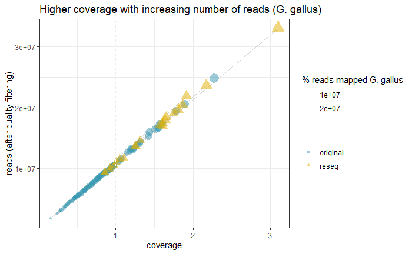

```r
theme_set(theme_bw()) #set theme to black and white

#relate number of reads (y-axis) to final coverage (x-axis), color according to sequencing run (original vs. resequenced) and sample type, shape according to original run or resequencing
ggplot(data_overview_Gg, aes(x = average_coverage, y = reads_post_trim_total, color = original_reseq, shape = original_reseq)) +

  scale_colour_manual(values = two_colors, na.value = 1) +

  geom_line(aes(group = ID), color = "lightgrey", show.legend = FALSE) + #connect same samples

  geom_point(alpha = 0.5, aes(size = reads_mapped_and_paired, group = ID)) + #add points with slight transparency

  geom_vline(xintercept = 1, linetype = "dashed") + #include vertical line to show coverage cutoff

    #scale_y_log10(breaks = scales::trans_breaks("log10", function(x) 10^x), labels = scales::trans_format("log10", scales::math_format(10^.x))) + #make y-axis logarithmic

  #scale_x_log10() + #make x-axis logarithmic

  #annotation_logticks() +

  labs(x = "coverage", y = "reads (after quality filtering)",
       size = "% reads mapped G. gallus", color ="", shape = "") +

  ggtitle("Higher coverage with increasing number of reads (G. gallus)")
```

```r
NA
```

C-Curve

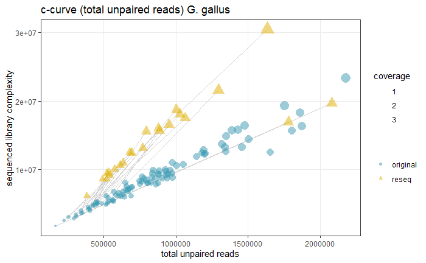

```r
#relate number of distinct reads (y-axis) to total reads (x-axis), color and shape according to original run or resequencing
ggplot(data_overview_Gg, aes(x = unpaired_reads_examined_for_deduplication, y = sequenced_library_complexity, color = original_reseq, shape = original_reseq)) +

  geom_line(aes(group = ID), color = "lightgrey", show.legend = FALSE) + #connect same samples

  geom_point(alpha = 0.5, aes(size = average_coverage, group = ID)) + #add points with slight transparency

  theme(panel.grid.minor.x = element_blank(), panel.grid.minor.y = element_blank()) + #remove x/y-axis grid lines

  labs(x = "total unpaired reads", y = "sequenced library complexity",
       size = "coverage", color ="", shape = "") + #adjust axis and legend labels

   scale_colour_manual(values = two_colors, na.value = 1) +

  ggtitle("c-curve (total unpaired reads) G. gallus")
```

```r
NA
```

comparison to total surviving reads from Trimmomatic to distinct mapped reads

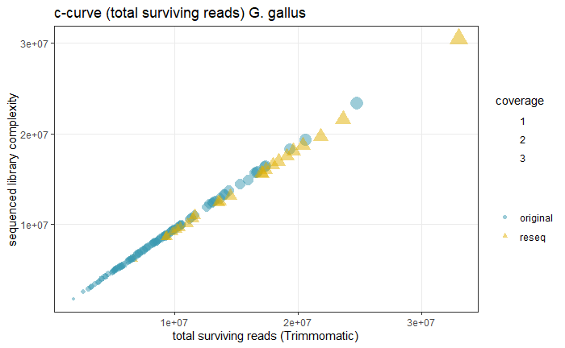

```r
#relate number of distinct reads (y-axis) to total surviving reads (x-axis), color  and sample type, shape according to original run or resequencing
ggplot(data_overview_Gg, aes(x =  reads_post_trim_total, y = sequenced_library_complexity, color = original_reseq, shape = original_reseq)) +

  scale_colour_manual(values = two_colors) +

  geom_point(alpha = 0.5, aes(size = average_coverage, group = ID)) + #add points with slight transparency

  theme(panel.grid.minor.x = element_blank(), panel.grid.minor.y = element_blank()) + #remove x/y-axis grid lines

  labs(x = "total surviving reads (Trimmomatic)", y = "sequenced library complexity",
       size = "coverage", color ="", shape = "") +  #adjust axis and legend labels

  ggtitle("c-curve (total surviving reads) G. gallus")
```

```r
NA
NA
NA
```

plot overview of sequencing reads processing steps with a ridge plot

```r
reads_overview_Gg <- select(data_overview_Gg, ID, reads_pre_trim_total, reads_post_trim_total, reads_mapped, reads_mapped_and_paired, paired_reads_examined_for_deduplication, paired_read_duplicates, original_reseq)

#create column with nonduplicates
reads_overview_Gg <- mutate(reads_overview_Gg, nonduplicates = 2*(paired_reads_examined_for_deduplication -  paired_read_duplicates))

names(reads_overview_Gg) <-  c("ID", "raw", "filtered", "mapped", "mapped & paired", "paired examined", "paired duplicates", "original_reseq", "2 * paired non-duplicates")

#reorganize data to have all read information in singel column
reads_overview_Gg <- gather(reads_overview_Gg, "raw", "filtered", "mapped", "mapped & paired", "2 * paired non-duplicates", key = "processing_step", value = "reads")

reads_overview_Gg <- mutate(reads_overview_Gg, mio_reads = reads/1000000)

reads_overview_Gg$processing_step <- as.factor(reads_overview_Gg$processing_step)

str(reads_overview_Gg)
```

```
'data.frame':   595 obs. of  7 variables:
 $ ID               : chr  "W1350" "W1398" "W1429" "W1502" ...
 $ paired examined  : int  2773267 2223740 2065744 4713529 4035984 1958287 2500242 4225935 3857589 2755435 ...
 $ paired duplicates: int  188533 99345 86903 223509 165399 97469 100112 176039 163677 112583 ...
 $ original_reseq   : chr  "reseq" "original" "original" "original" ...
 $ processing_step  : Factor w/ 5 levels "2 * paired non-duplicates",..: 5 5 5 5 5 5 5 5 5 5 ...
 $ reads            : num  7688126 6720264 6069840 13390576 12081324 ...
 $ mio_reads        : num  7.69 6.72 6.07 13.39 12.08 ...
```

```
`guides(<scale> = FALSE)` is deprecated. Please use `guides(<scale> = "none")` instead.
```

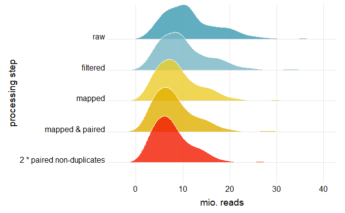

```r
#step_color <- c("#440154FF", "#5DC863FF", "#21908CFF", "#3B528BFF","#FDE725FF")

Five_colors <- c(wes_palette("Zissou1")[5], wes_palette("Zissou1")[2], wes_palette("Zissou1")[3], wes_palette("Zissou1")[4], wes_palette("Zissou1")[1])

ggplot(reads_overview_Gg, aes(x = mio_reads, y = fct_reorder(processing_step, reads, .fun = "max"), fill = processing_step)) +

   geom_density_ridges(alpha = 0.8, color = "white", scale = 1.5, rel_min_height = 0.01) +

  scale_fill_cyclical(values = Five_colors) +

  labs (x = "mio. reads", y = "processing step") +

  guides(fill = FALSE) +

  theme_ridges(center = TRUE)
```

plot coverage and st.dv.

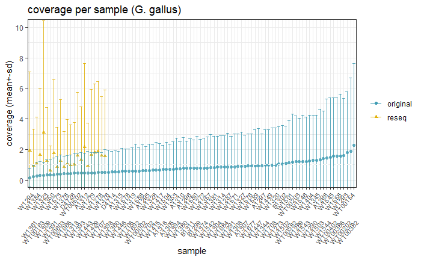

```r
#plot coverage (y-axis) including st.dev for every sample (x-axis), color according to original run or resequencing
ggplot(filter(data_overview_Gg, original_reseq == "original"), aes(x = reorder(ID, average_coverage), y = average_coverage, color = original_reseq, shape = original_reseq)) +

  scale_colour_manual(values = two_colors) +

  geom_point(aes(y=average_coverage), alpha = 0.8) +

  geom_point(data = filter(data_overview_Gg, original_reseq == "reseq"), aes(y=average_coverage), alpha = 0.8) +

  geom_errorbar(data = filter(data_overview_Gg, original_reseq == "reseq"), aes(ymin = average_coverage - average_coverage_stdev, ymax = average_coverage + average_coverage_stdev), alpha = 0.8) +

  geom_errorbar(aes(ymin = average_coverage - average_coverage_stdev, ymax = average_coverage + average_coverage_stdev), alpha = 0.8) +

  geom_hline(yintercept = 1, linetype = "dashed") + #include horizontal line to show coverage cutoff at 1X

  geom_hline(yintercept = median_final_coverage_Gg, linetype = "dotted") +

  coord_cartesian(ylim = c(0, 10)) + #adjust y axis

  scale_y_continuous(breaks = c(0, 2, 4, 6, 8, 10)) +

  labs(x = "sample", y = "coverage (mean+-sd)",
       color ="", shape = "") + #adjust axis and legend labels

  theme(axis.text.x = element_text(angle = 50, vjust = 1, hjust = 1, size = 8)) +

  scale_x_discrete(guide = guide_axis(n.dodge=2)) +  #avoid overlap of x-axis labels

  ggtitle("coverage per sample (G. gallus)")
```

```r
NA
NA
```

## Relatedness data

### ngsRelate

This is an assessment of the ngsRelate results produced by the Nextflow pipleine created by Ben Hume/SeqAna. The data is saved in the folder `pipeline` in `ngsrelate` as *relatedness.isec.0002.exMito.thinned.ngsrelate.w.sample.names.results*. We now use the results excluding replicated samples and the Z chromosome, which are stored in `pipeline/no_repeats_no_Z_relatedness_results/nextflow_output/ngsrelate`.

```r
ngsRelate_results <- read.delim("data/pipeline/no_repeats_no_Z_relatedness_results/nextflow_output/ngsrelate/relatedness.isec.0002.exMito.thinned.ngsrelate.results", header = TRUE,  as.is = TRUE)
str(ngsRelate_results)
```

```
'data.frame':   4560 obs. of  35 variables:
 $ a                     : int  0 0 0 0 0 0 0 0 0 0 ...
 $ b                     : int  1 2 3 4 5 6 7 8 9 10 ...
 $ ida                   : chr  "RGID1_S83" "RGID1_S83" "RGID1_S83" "RGID1_S83" ...
 $ idb                   : chr  "RGID1_S82" "RGID1_S29" "RGID1_S2" "RGID2_S13" ...
 $ nSites                : int  614924 527474 430254 612597 599536 515211 460041 591284 452116 488952 ...
 $ J9                    : num  0.823 0.636 0.427 0.863 0.864 ...
 $ J8                    : num  0.0 1.4e-05 1.0e-06 0.0 1.0e-06 0.0 0.0 1.0e-06 3.0e-06 0.0 ...
 $ J7                    : num  0.0895 0.0603 0.1184 0.0536 0.0468 ...
 $ J6                    : num  0 0.208 0.412 0 0 ...
 $ J5                    : num  4e-06 0e+00 1e-05 0e+00 0e+00 0e+00 0e+00 0e+00 0e+00 0e+00 ...
 $ J4                    : num  0.05385 0 0 0.030893 0.000062 ...
 $ J3                    : num  0e+00 2e-06 0e+00 0e+00 0e+00 0e+00 0e+00 2e-06 0e+00 0e+00 ...
 $ J2                    : num  0.0336 0.0959 0.0429 0.0528 0.0888 ...
 $ J1                    : num  1.0e-06 0.0 4.3e-05 1.0e-06 0.0 0.0 0.0 1.0e-06 0.0 0.0 ...
```

[output cut: 21 more lines]

We join together the relatedness estimates with the sample information, to know the identity of the dyads

```r
#rename "ida" and "idb" to "RGSM_a" and "RGSM-b"
ngsRelate_results <- rename(ngsRelate_results, "RGSM_a" = "ida")
ngsRelate_results <- rename(ngsRelate_results, "RGSM_b" = "idb")

#create a new column that includes RGSM_dyad
ngsRelate_results$RGSM_dyad <- if_else(ngsRelate_results$RGSM_a < ngsRelate_results$RGSM_b, paste(ngsRelate_results$RGSM_a, ngsRelate_results$RGSM_b, sep = "-"), paste(ngsRelate_results$RGSM_b, ngsRelate_results$RGSM_a, sep = "-"))

#first include ID of individual a
ngsRelate_results_ID <- left_join(ngsRelate_results, seqlib_overview[6:7], by = c("RGSM_a" = "RGSM"))

#rename "ID" to "ID_a"
ngsRelate_results_ID <- rename(ngsRelate_results_ID, "ID_a" = "ID")

#now include ID of individual b
ngsRelate_results_ID <- left_join(ngsRelate_results_ID, seqlib_overview[6:7], by = c("RGSM_b" = "RGSM"))

#rename "ID" to "ID_b"
ngsRelate_results_ID <- rename(ngsRelate_results_ID, "ID_b" = "ID")

#create a new column that includes the dyad
ngsRelate_results_ID$dyad <- if_else(ngsRelate_results_ID$ID_a < ngsRelate_results_ID$ID_b, paste(ngsRelate_results_ID$ID_a, ngsRelate_results_ID$ID_b, sep = "-"), paste(ngsRelate_results_ID$ID_b, ngsRelate_results_ID$ID_a, sep = "-"))

#remove duplicates ##maybe not necessary anymore

ngsRelate_results_ID <- distinct(ngsRelate_results_ID)
```

We also include the group information

```r
#first include group of individual a
ngsRelate_results_sample_info <- left_join(ngsRelate_results_ID, sample_info, by = c("ID_a" = "ID"))

#rename "Group_ID" to "a_Group" and "sex" to "a_sex"
ngsRelate_results_sample_info <- rename(ngsRelate_results_sample_info, "a_Group" = "Group_ID")
ngsRelate_results_sample_info <- rename(ngsRelate_results_sample_info, "a_sex" = "sex")

#then include group of individual b
ngsRelate_results_sample_info <- left_join(ngsRelate_results_sample_info, sample_info, by = c("ID_b" = "ID"))

#rename "Group_ID" to "b_Group" and "sex" to "b_sex"
ngsRelate_results_sample_info <- rename(ngsRelate_results_sample_info, "b_Group" = "Group_ID")
ngsRelate_results_sample_info <- rename(ngsRelate_results_sample_info, "b_sex" = "sex")
```

```r
#which group IDs are there?
sort(unique(ngsRelate_results_sample_info$a_Group))
```

```
 [1] "5509"         "5512"         "5931-5938"    "dump"         "mpala"        "mpala_chicks" "ROOP"
 [8] "RRWB"         "wing_tags"    "wt025"
```

```r
sort(unique(ngsRelate_results_sample_info$b_Group))
```

```
 [1] "5509"         "5512"         "5931-5938"    "dump"         "mpala"        "mpala_chicks" "ROOP"
 [8] "RRWB"         "wing_tags"    "wt025"
```

```r
#create new column that specifies if individuals are from same or different groups
ngsRelate_results_sample_info <- ngsRelate_results_sample_info %>%
  mutate(dyad_group = case_when(ID_a == ID_b ~ "identical",
                                a_Group == b_Group ~ "intragroup",
                                a_Group != b_Group ~ "intergroup"))

unique(ngsRelate_results_sample_info$dyad_group)
```

```
[1] "intragroup" "intergroup"
```

```r
#create new column that specifies if individuals have same or different sex
ngsRelate_results_sample_info <- ngsRelate_results_sample_info %>%
  mutate(dyad_sex = case_when(ID_a == ID_b ~ "identical",
                                a_sex == b_sex ~ "same sex",
                                a_sex != b_sex ~ "male-female"))

#recode dyads for individuals with undetermined sex to NA
ngsRelate_results_sample_info$dyad_sex[ngsRelate_results_sample_info$a_sex == "u"] <- NA
ngsRelate_results_sample_info$dyad_sex[ngsRelate_results_sample_info$b_sex == "u"] <- NA

#recode same sex dyads to male or female
ngsRelate_results_sample_info$dyad_sex[ngsRelate_results_sample_info$dyad_sex == "same sex" &
                                         ngsRelate_results_sample_info$a_sex == "f"] <- "female"
ngsRelate_results_sample_info$dyad_sex[ngsRelate_results_sample_info$dyad_sex == "same sex" &
                                         ngsRelate_results_sample_info$a_sex == "m"] <- "male"


unique(ngsRelate_results_sample_info$dyad_sex)
```

```
[1] "male-female" "female"      "male"
```

Let’s have a closer look at the samples that were sequenced twice

```r
#find samples that were sequenced twice
duplicates <- filter(ngsRelate_results_sample_info, ID_a == ID_b)

#average relatedness of these duplicted inidividuals
mean(duplicates$rab)
```

```
[1] NaN
```

```r
#range
range(duplicates$rab)
```

[output not shown]

```
[1]  Inf -Inf
```

Create subset with at least 250k SNPs

```r
ngsRelate_results_sample_info_250k <- filter(ngsRelate_results_sample_info, nSites >= 250000)

unique(ngsRelate_results_sample_info_250k$dyad_group)
```

```
[1] "intragroup" "intergroup"
```

To get an overview of the distribution of relatedness coefficients, we plot pairwise relatedness for all dyads

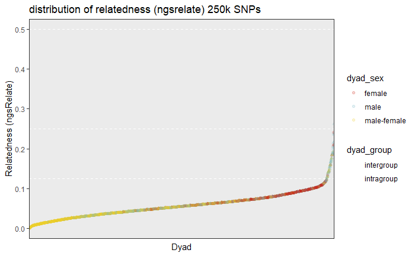

```r
#plot relatedness rab (y-axis) for every dyad (x-axis), ordered from low to high relatedness and colored according to inter- or intragroup dyad

ggplot(ngsRelate_results_sample_info_250k, aes(x = reorder(dyad, rab), y = rab, color = dyad_sex, shape = dyad_group)) +

  scale_colour_manual(values = three_colors) +

  geom_point(alpha = 0.2, aes(y = rab)) + #plot relatedness estimates as points

  geom_hline(yintercept = c(0.125, 0.25, 0.5), linetype = "dashed") + #include horizontal line to show traditional kinship categories

  labs( x = "Dyad", y = "Relatedness (ngsRelate)") +

  theme(axis.text.x = element_blank(), axis.ticks.x = element_blank()) +

  ggtitle("distribution of relatedness (ngsrelate) 250k SNPs")
```

```r
NA
NA
```

check correlation between number of SNPs and sex

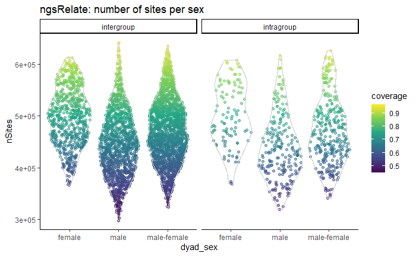

```r
#plot nSites (y-axis) and for the different categories of sex of dyad (x-axis) colored according to coverage

ggplot(ngsRelate_results_sample_info, aes(x = dyad_sex, y = nSites, color = coverage)) +

  geom_sina(alpha = 0.5) +

  scale_colour_viridis_c(na.value = 1) +

  geom_violin(alpha = 0)+

  facet_grid(.~dyad_group) +

 ggtitle("ngsRelate: number of sites per sex")
```

Compare relatedness estimates according to group and sex

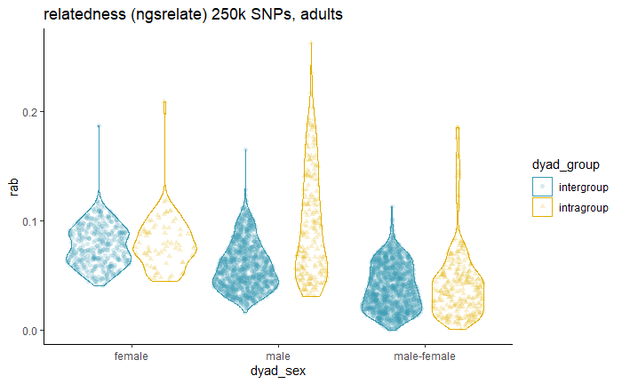

```r
#plot relatedness rab (y-axis) for the different categories of sex of dyad (x-axis) colored according to group membership

ggplot(filter(ngsRelate_results_sample_info_250k, a_Group != "mpala_chicks", b_Group != "mpala_chicks"), aes(x = dyad_sex, y = rab, color = dyad_group, shape = dyad_group)) +

  geom_sina(alpha = 0.2) +

  geom_violin(alpha = 0) +

  scale_colour_manual(values = two_colors) +

 ggtitle("relatedness (ngsrelate) 250k SNPs, adults")
```

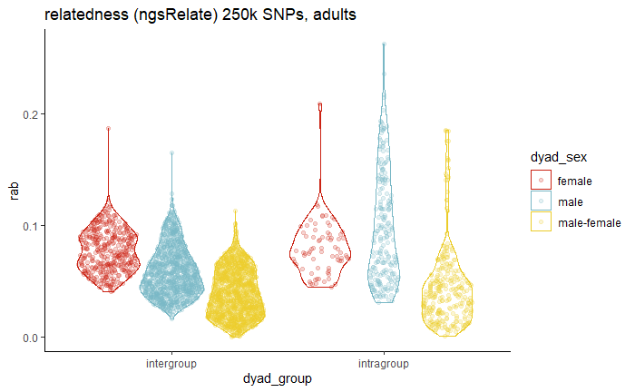

```r
#plot relatedness rab (y-axis) for the different categories of sex of dyad (x-axis) colored according to group membership

ggplot(filter(ngsRelate_results_sample_info_250k, a_Group != "mpala_chicks", b_Group != "mpala_chicks"), aes(x = dyad_group, y = rab, color = dyad_sex)) +

  geom_sina(alpha = 0.2) +

  geom_violin(alpha = 0) +

  scale_colour_manual(values = three_colors, na.value = 1) +

 ggtitle("relatedness (ngsRelate) 250k SNPs, adults")
```

#### ngsRelate mapped to G. gallus

This is an assessment of the ngsRelate results produced by the Nextflow pipleine created by Ben Hume/SeqAna with the reference genome *G. gallus*. The data is saved in the folder `pipeline` in `Ref_Ggallus` as *relatedness.isec.0002.exMito.thinned.ngsrelate.results*.

```r
ngsRelate_results_gg <- read.delim("data/pipeline/Ref_Ggallus/relatedness.isec.0002.exMito.thinned.ngsrelate.results", header = TRUE,  as.is = TRUE)
str(ngsRelate_results_gg)
```

```
'data.frame':   4560 obs. of  35 variables:
 $ a                     : int  0 0 0 0 0 0 0 0 0 0 ...
 $ b                     : int  1 2 3 4 5 6 7 8 9 10 ...
 $ ida                   : chr  "RGID1_S41" "RGID1_S41" "RGID1_S41" "RGID1_S41" ...
 $ idb                   : chr  "RGID2_S8" "RGID1_S95" "RGID1_S45" "RGID1_S58" ...
 $ nSites                : int  270468 206664 225465 229637 240331 243442 259307 267885 227803 258285 ...
 $ J9                    : num  0.485 0.482 0.534 0.537 0.545 ...
 $ J8                    : num  0.000003 0.000161 0 0.000001 0.000068 0.000053 0.000035 0.00002 0.000016 0 ...
 $ J7                    : num  0.0431 0 0 0 0.00144 ...
 $ J6                    : num  0 0.089773 0.017946 0.010294 0.000007 ...
 $ J5                    : num  0 0.00837 0.00872 0.01159 0.00646 ...
 $ J4                    : num  0.4019 0.0472 0.1137 0.1029 0.159 ...
 $ J3                    : num  0 0.008289 0.000395 0.003856 0.000031 ...
 $ J2                    : num  0.0703 0.3642 0.3256 0.3343 0.2878 ...
 $ J1                    : num  1e-06 0e+00 2e-06 0e+00 0e+00 6e-06 2e-06 1e-06 1e-06 0e+00 ...
```

[output cut: 21 more lines]

We join together the relatedness estimates with the sample information, to know the identity of the dyads

```r
#rename "ida" and "idb" to "RGSM_a" and "RGSM-b"
ngsRelate_results_gg <- rename(ngsRelate_results_gg, "RGSM_a" = "ida")
ngsRelate_results_gg <- rename(ngsRelate_results_gg, "RGSM_b" = "idb")

#create a new column that includes RGSM_dyad
ngsRelate_results_gg$RGSM_dyad <- if_else(ngsRelate_results_gg$RGSM_a < ngsRelate_results_gg$RGSM_b, paste(ngsRelate_results_gg$RGSM_a, ngsRelate_results_gg$RGSM_b, sep = "-"), paste(ngsRelate_results_gg$RGSM_b, ngsRelate_results_gg$RGSM_a, sep = "-"))

#first include ID of individual a
ngsRelate_results_ID_gg <- left_join(ngsRelate_results_gg, seqlib_overview[6:7], by = c("RGSM_a" = "RGSM"))

#rename "ID" to "ID_a"
ngsRelate_results_ID_gg <- rename(ngsRelate_results_ID_gg, "ID_a" = "ID")

#now include ID of individual b
ngsRelate_results_ID_gg <- left_join(ngsRelate_results_ID_gg, seqlib_overview[6:7], by = c("RGSM_b" = "RGSM"))

#rename "ID" to "ID_b"
ngsRelate_results_ID_gg <- rename(ngsRelate_results_ID_gg, "ID_b" = "ID")

#create a new column that includes the dyad
ngsRelate_results_ID_gg$dyad <- if_else(ngsRelate_results_ID_gg$ID_a < ngsRelate_results_ID_gg$ID_b, paste(ngsRelate_results_ID_gg$ID_a, ngsRelate_results_ID_gg$ID_b, sep = "-"), paste(ngsRelate_results_ID_gg$ID_b, ngsRelate_results_ID_gg$ID_a, sep = "-"))

#remove duplicates ##maybe not necessary anymore

ngsRelate_results_ID_gg <- distinct(ngsRelate_results_ID_gg)
```

We also include the group information

```r
#first include group of individual a
ngsRelate_results_sample_info_gg <- left_join(ngsRelate_results_ID_gg, sample_info, by = c("ID_a" = "ID"))

#rename "Group_ID" to "a_Group" and "sex" to "a_sex"
ngsRelate_results_sample_info_gg <- rename(ngsRelate_results_sample_info_gg, "a_Group" = "Group_ID")
ngsRelate_results_sample_info_gg <- rename(ngsRelate_results_sample_info_gg, "a_sex" = "sex")

#then include group of individual b
ngsRelate_results_sample_info_gg <- left_join(ngsRelate_results_sample_info_gg, sample_info, by = c("ID_b" = "ID"))

#rename "Group_ID" to "b_Group" and "sex" to "b_sex"
ngsRelate_results_sample_info_gg<- rename(ngsRelate_results_sample_info_gg, "b_Group" = "Group_ID")
ngsRelate_results_sample_info_gg <- rename(ngsRelate_results_sample_info_gg, "b_sex" = "sex")
```

```r
#which group IDs are there?
sort(unique(ngsRelate_results_sample_info_gg$a_Group))
```

```
 [1] "5509"         "5512"         "5931-5938"    "dump"         "mpala"        "mpala_chicks" "ROOP"
 [8] "RRWB"         "wing_tags"    "wt025"
```

```r
sort(unique(ngsRelate_results_sample_info_gg$b_Group))
```

```
 [1] "5509"         "5512"         "5931-5938"    "dump"         "mpala"        "mpala_chicks" "ROOP"
 [8] "RRWB"         "wing_tags"    "wt025"
```

```r
#create new column that specifies if individuals are from same or different groups
ngsRelate_results_sample_info_gg <- ngsRelate_results_sample_info_gg %>%
  mutate(dyad_group = case_when(ID_a == ID_b ~ "identical",
                                a_Group == b_Group ~ "intragroup",
                                a_Group != b_Group ~ "intergroup"))

unique(ngsRelate_results_sample_info_gg$dyad_group)
```

```
[1] "intergroup" "intragroup" NA
```

```r
#create new column that specifies if individuals have same or different sex
ngsRelate_results_sample_info_gg <- ngsRelate_results_sample_info_gg %>%
  mutate(dyad_sex = case_when(ID_a == ID_b ~ "identical",
                                a_sex == b_sex ~ "same sex",
                                a_sex != b_sex ~ "male-female"))

#recode dyads for individuals with undetermined sex to NA
ngsRelate_results_sample_info_gg$dyad_sex[ngsRelate_results_sample_info_gg$a_sex == "u"] <- NA
ngsRelate_results_sample_info_gg$dyad_sex[ngsRelate_results_sample_info_gg$b_sex == "u"] <- NA

#recode same sex dyads to male or female
ngsRelate_results_sample_info_gg$dyad_sex[ngsRelate_results_sample_info_gg$dyad_sex == "same sex" &
                                         ngsRelate_results_sample_info_gg$a_sex == "f"] <- "female"
ngsRelate_results_sample_info_gg$dyad_sex[ngsRelate_results_sample_info_gg$dyad_sex == "same sex" &
                                         ngsRelate_results_sample_info_gg$a_sex == "m"] <- "male"


unique(ngsRelate_results_sample_info_gg$dyad_sex)
```

```
[1] "male-female" "male"        NA            "female"
```

Let’s have a closer look at the samples that were sequenced twice

```r
#find samples that were sequenced twice
duplicates_gg <- filter(ngsRelate_results_sample_info_gg, ID_a == ID_b)

#average relatedness of these duplicted inidividuals
mean(duplicates_gg$rab)
```

```
[1] NaN
```

```r
#range
range(duplicates_gg$rab)
```

[output not shown]

```
[1]  Inf -Inf
```

Create subset with at least 250k SNPs

```r
ngsRelate_results_sample_info_250k_gg <- filter(ngsRelate_results_sample_info_gg, nSites >= 250000)
```

To get an overview of the distribution of relatedness coefficients, we plot pairwise relatedness for all dyads

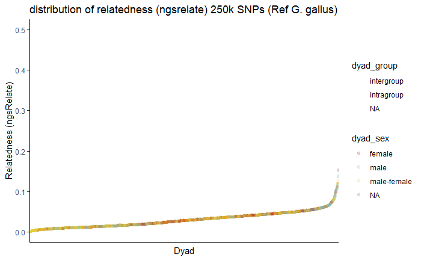

```r
#plot relatedness rab (y-axis) for every dyad (x-axis), ordered from low to high relatedness and colored according to inter- or intragroup dyad

ggplot(ngsRelate_results_sample_info_250k_gg, aes(x = reorder(dyad, rab), y = rab, color = dyad_sex, shape = dyad_group)) +

  scale_colour_manual(values = three_colors) +

  geom_point(alpha = 0.2, aes(y = rab)) + #plot relatedness estimates as points

  geom_hline(yintercept = c(0.125, 0.25, 0.5), linetype = "dashed") + #include horizontal line to show traditional kinship categories

  labs( x = "Dyad", y = "Relatedness (ngsRelate)") +

  theme(axis.text.x = element_blank(), axis.ticks.x = element_blank()) +

  ggtitle("distribution of relatedness (ngsrelate) 250k SNPs (Ref G. gallus)")
```

```r
NA
NA
```

check correlation between number of SNPs and sex

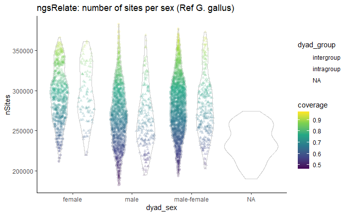

```r
#plot nSites (y-axis) and for the different categories of sex of dyad (x-axis) colored according to coverage

ggplot(ngsRelate_results_sample_info_gg, aes(x = dyad_sex, y = nSites, color = coverage, shape = dyad_group)) +

  geom_sina(alpha = 0.2) +

  scale_colour_viridis_c(na.value = 1) +

  geom_violin(alpha = 0) +

 ggtitle("ngsRelate: number of sites per sex (Ref G. gallus)")
```

Compare relatedness estimates according to group and sex

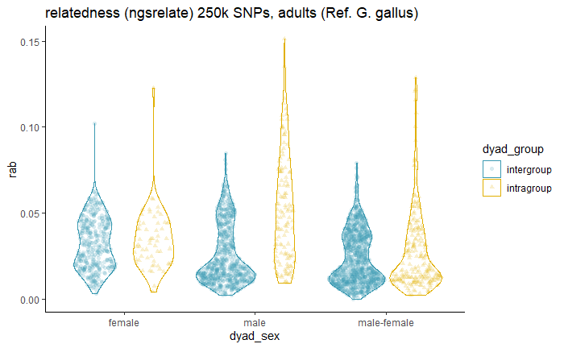

```r
#plot relatedness rab (y-axis) for the different categories of sex of dyad (x-axis) colored according to group membership

ggplot(filter(ngsRelate_results_sample_info_250k_gg, a_Group != "mpala_chicks", b_Group != "mpala_chicks"), aes(x = dyad_sex, y = rab, color = dyad_group, shape = dyad_group)) +

  geom_sina(alpha = 0.2) +

  geom_violin(alpha = 0) +

  scale_colour_manual(values = two_colors) +

 ggtitle("relatedness (ngsrelate) 250k SNPs, adults (Ref. G. gallus)")
```

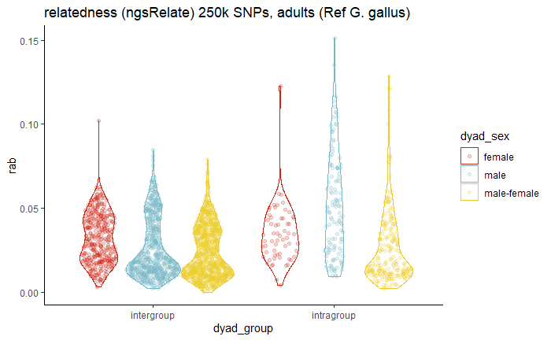

```r
#plot relatedness rab (y-axis) for the different categories of sex of dyad (x-axis) colored according to group membership

ggplot(filter(ngsRelate_results_sample_info_250k_gg, a_Group != "mpala_chicks", b_Group != "mpala_chicks"), aes(x = dyad_group, y = rab, color = dyad_sex)) +

  geom_sina(alpha = 0.2) +

  geom_violin(alpha = 0) +

  scale_colour_manual(values = three_colors, na.value = 1) +

 ggtitle("relatedness (ngsRelate) 250k SNPs, adults (Ref G. gallus)")
```

### lcmlkin

We now use the results excluding replicated samples, which are stored in `pipeline/no_repeats_relatedness_results/nf_results/lcmlkin`

```r
lcmlkin_results <- read.delim("data/pipeline/no_repeats_relatedness_results/nf_results/lcmlkin/relatedness.isec.0002.exMito.thinned.lcmlkin.results", header = TRUE,  as.is = TRUE)
str(lcmlkin_results)
```

```
'data.frame':   4560 obs. of  7 variables:
 $ Ind1  : chr  "RGID1_S83" "RGID1_S83" "RGID1_S83" "RGID1_S83" ...
 $ Ind2  : chr  "RGID1_S49" "RGID2_S13" "RGID1_S89" "RGID2_S11" ...
 $ k0_hat: num  0.911 0.878 0.835 0.815 0.863 0.904 0.814 0.816 0.877 0.903 ...
 $ k1_hat: num  0 0.002 0.004 0.003 0.002 0.003 0.005 0.003 0.002 0.003 ...
 $ k2_hat: num  0.089 0.12 0.162 0.182 0.134 0.093 0.182 0.18 0.121 0.094 ...
 $ pi_HAT: num  0.089 0.121 0.164 0.183 0.136 0.094 0.184 0.182 0.122 0.096 ...
 $ nbSNP : int  617110 729018 615902 622500 713042 579737 518643 623265 704472 603659 ...
```

We join together the relatedness estimates with the sample information, to know the identity of the dyads

```r
#rename "ida" and "idb" to "RGSM_a" and "RGSM-b"
lcmlkin_results <- rename(lcmlkin_results, "RGSM_a" = "Ind1")
lcmlkin_results <- rename(lcmlkin_results, "RGSM_b" = "Ind2")

#create a new column that includes RGSM_dyad
lcmlkin_results$RGSM_dyad <- if_else(lcmlkin_results$RGSM_a < lcmlkin_results$RGSM_b, paste(lcmlkin_results$RGSM_a, lcmlkin_results$RGSM_b, sep = "-"), paste(lcmlkin_results$RGSM_b, lcmlkin_results$RGSM_a, sep = "-"))

#first include ID of individual a
lcmlkin_results_ID <- left_join(lcmlkin_results, seqlib_overview[6:7], by = c("RGSM_a" = "RGSM"))

#rename "ID" to "ID_a"
lcmlkin_results_ID <- rename(lcmlkin_results_ID, "ID_a" = "ID")

#now include ID of individual b
lcmlkin_results_ID <- left_join(lcmlkin_results_ID, seqlib_overview[6:7], by = c("RGSM_b" = "RGSM"))

#rename "ID" to "ID_b"
lcmlkin_results_ID <- rename(lcmlkin_results_ID, "ID_b" = "ID")

#create a new column that includes the dyad
lcmlkin_results_ID$dyad <- if_else(lcmlkin_results_ID$ID_a < lcmlkin_results_ID$ID_b, paste(lcmlkin_results_ID$ID_a, lcmlkin_results_ID$ID_b, sep = "-"), paste(lcmlkin_results_ID$ID_b, lcmlkin_results_ID$ID_a, sep = "-"))

#remove duplicates ##maybe not necessary anymore

lcmlkin_results_ID <- distinct(lcmlkin_results_ID)
```

We also include the group information

```r
#first include group of individual a
lcmlkin_results_sample_info <- left_join(lcmlkin_results_ID, sample_info, by = c("ID_a" = "ID"))

#rename "Group_ID" to "a_Group"
lcmlkin_results_sample_info <- rename(lcmlkin_results_sample_info, "a_Group" = "Group_ID")
lcmlkin_results_sample_info <- rename(lcmlkin_results_sample_info, "a_sex" = "sex")

#then include group of individual b
lcmlkin_results_sample_info <- left_join(lcmlkin_results_sample_info, sample_info, by = c("ID_b" = "ID"))
lcmlkin_results_sample_info <- rename(lcmlkin_results_sample_info, "b_sex" = "sex")

#rename "Group_ID" to "b_Group"
lcmlkin_results_sample_info <- rename(lcmlkin_results_sample_info, "b_Group" = "Group_ID")
```

```r
#create new column that specifies if individuals are from same or different groups
lcmlkin_results_sample_info <- lcmlkin_results_sample_info %>%
  mutate(dyad_group = if_else(a_Group == b_Group, "intra", "inter"))
str(lcmlkin_results_sample_info)
```

```
'data.frame':   4560 obs. of  16 variables:
 $ RGSM_a    : chr  "RGID1_S83" "RGID1_S83" "RGID1_S83" "RGID1_S83" ...
 $ RGSM_b    : chr  "RGID1_S49" "RGID2_S13" "RGID1_S89" "RGID2_S11" ...
 $ k0_hat    : num  0.911 0.878 0.835 0.815 0.863 0.904 0.814 0.816 0.877 0.903 ...
 $ k1_hat    : num  0 0.002 0.004 0.003 0.002 0.003 0.005 0.003 0.002 0.003 ...
 $ k2_hat    : num  0.089 0.12 0.162 0.182 0.134 0.093 0.182 0.18 0.121 0.094 ...
 $ pi_HAT    : num  0.089 0.121 0.164 0.183 0.136 0.094 0.184 0.182 0.122 0.096 ...
 $ nbSNP     : int  617110 729018 615902 622500 713042 579737 518643 623265 704472 603659 ...
 $ RGSM_dyad : chr  "RGID1_S49-RGID1_S83" "RGID1_S83-RGID2_S13" "RGID1_S83-RGID1_S89" "RGID1_S83-RGID2_S11" ...
 $ ID_a      : chr  "WT00386" "WT00386" "WT00386" "WT00386" ...
 $ ID_b      : chr  "A1307" "A1312" "W1671" "W1673" ...
 $ dyad      : chr  "A1307-WT00386" "A1312-WT00386" "W1671-WT00386" "W1673-WT00386" ...
 $ a_Group   : chr  "mpala_chicks" "mpala_chicks" "mpala_chicks" "mpala_chicks" ...
 $ a_sex     : chr  "f" "f" "f" "f" ...
 $ b_Group   : chr  "wing_tags" "wing_tags" "wt025" "wt025" ...
 $ b_sex     : chr  "m" "m" "f" "f" ...
 $ dyad_group: chr  "inter" "inter" "inter" "inter" ...
```

```r
#create new column that specifies if individuals have same or different sex
lcmlkin_results_sample_info <- lcmlkin_results_sample_info %>%
  mutate(dyad_sex = case_when(ID_a == ID_b ~ "identical",
                                a_sex == b_sex ~ "same sex",
                                a_sex != b_sex ~ "male-female"))

#recode dyads for individuals with undetermined sex to NA
lcmlkin_results_sample_info$dyad_sex[lcmlkin_results_sample_info$a_sex == "u"] <- NA
lcmlkin_results_sample_info$dyad_sex[lcmlkin_results_sample_info$b_sex == "u"] <- NA

#recode same sex dyads to male or female
lcmlkin_results_sample_info$dyad_sex[lcmlkin_results_sample_info$dyad_sex == "same sex" &
                                         lcmlkin_results_sample_info$a_sex == "f"] <- "female"
lcmlkin_results_sample_info$dyad_sex[lcmlkin_results_sample_info$dyad_sex == "same sex" &
                                         lcmlkin_results_sample_info$a_sex == "m"] <- "male"


unique(lcmlkin_results_sample_info$dyad_sex)
```

```
[1] "male-female" "female"      "male"
```

Let’s have a closer look at the samples that were sequenced twice

```r
#find samples that were sequenced twice
duplicates_lcmlkin <- filter(lcmlkin_results_sample_info, ID_a == ID_b)

#average relatedness of these duplicted inidividuals
mean(duplicates_lcmlkin$pi_HAT)
```

```
[1] NaN
```

```r
#range
range(duplicates_lcmlkin$pi_HAT)
```

[output not shown]

```
[1]  Inf -Inf
```

Create subset with at least 300k SNPs

```r
lcmlkin_results_sample_info_300k <- filter(lcmlkin_results_sample_info, nbSNP >= 300000)
```

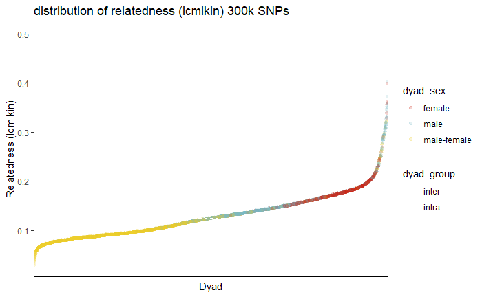

```r
#plot relatedness pi_HAT (y-axis) for every dyad (x-axis), ordered from low to high relatedness and colored according to inter- or intragroup dyad

ggplot(lcmlkin_results_sample_info_300k, aes(x = reorder(dyad, pi_HAT), y = pi_HAT, color = dyad_sex, shape = dyad_group)) +

  geom_point(alpha = 0.2, aes(y = pi_HAT)) + #plot relatedness estimates as points

  geom_hline(yintercept = c(0.125, 0.25, 0.5), linetype = "dashed") + #include horizontal line to show traditional kinship categories

  labs( x = "Dyad", y = "Relatedness (lcmlkin)") +

  theme(axis.text.x = element_blank(), axis.ticks.x = element_blank()) +

  scale_colour_manual(values = three_colors, na.value = 1) +

 ggtitle("distribution of relatedness (lcmlkin) 300k SNPs")
```

```r
NA
NA
```

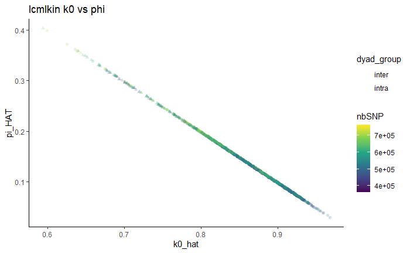

```r
theme_set(theme_classic())

#plot relatedness pi_HAT (y-axis) and corresponding k0 (x-axis) colored according to nbSNP

ggplot(lcmlkin_results_sample_info, aes(x = k0_hat, y = pi_HAT, color = nbSNP, shape = dyad_group)) +

  geom_point(alpha = 0.2) +

  scale_colour_viridis_c() +

 ggtitle("lcmlkin k0 vs phi")
```

```r
NA
NA
```

check correlation between number of SNPs and sex

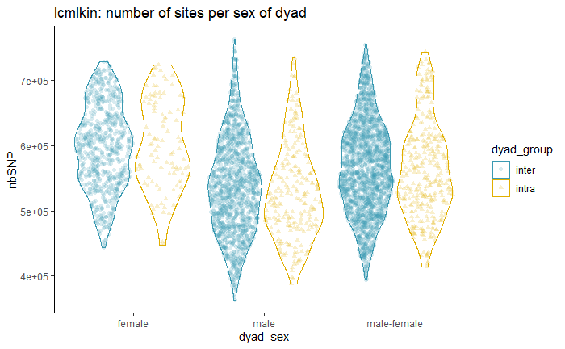

```r
#plot nbSNPs (y-axis) and for the different categories of sex of dyad (x-axis) colored according to dyad_group

ggplot(lcmlkin_results_sample_info, aes(x = dyad_sex, y = nbSNP, color = dyad_group, shape = dyad_group)) +

  geom_sina(alpha = 0.2) +

  geom_violin(alpha = 0) +

  scale_colour_manual(values = two_colors) +

 ggtitle("lcmlkin: number of sites per sex of dyad")
```

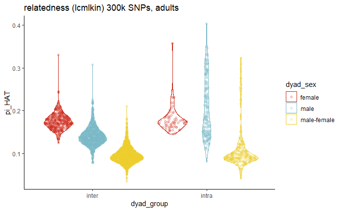

```r
#plot relatedness pi_HAT (y-axis) for the different categories of sex of dyad (x-axis) colored according to group membership

ggplot(filter(lcmlkin_results_sample_info_300k, a_Group != "mpala_chicks", b_Group != "mpala_chicks"), aes(x = dyad_group, y = pi_HAT, color = dyad_sex)) +

  geom_sina(alpha = 0.2) +

  geom_violin(alpha = 0) +

  scale_colour_manual(values = three_colors, na.value = 1) +

 ggtitle("relatedness (lcmlkin) 300k SNPs, adults")
```

#### lcmlkin mapped to G. gallus

We now use the results mapped to *G. gallus*, which are stored in `pipeline/Ref_Ggallus` as `relatedness.isec.0002.exMito.thiinned.lcmlkin.results`.

```r
lcmlkin_results_gg <- read.delim("data/pipeline/Ref_Ggallus/relatedness.isec.0002.exMito.thinned.lcmlkin.results", header = TRUE,  as.is = TRUE)
str(lcmlkin_results_gg)
```

```
'data.frame':   4560 obs. of  7 variables:
 $ Ind1  : chr  "RGID1_S41" "RGID1_S41" "RGID1_S41" "RGID1_S41" ...
 $ Ind2  : chr  "RGID1_S9" "RGID2_S5" "RGID1_S58" "RGID2_S8" ...
 $ k0_hat: num  0.91 0.901 0.915 0.898 0.922 0.912 0.911 0.917 0.841 0.905 ...
 $ k1_hat: num  0.006 0.005 0.006 0.005 0.006 0.005 0.007 0.006 0.007 0.006 ...
 $ k2_hat: num  0.083 0.094 0.079 0.097 0.072 0.083 0.082 0.077 0.152 0.089 ...
 $ pi_HAT: num  0.087 0.096 0.082 0.1 0.075 0.086 0.085 0.08 0.155 0.092 ...
 $ nbSNP : int  286213 317949 273986 320755 268764 306777 247274 308203 283383 289971 ...
```

We join together the relatedness estimates with the sample information, to know the identity of the dyads

```r
#rename "ida" and "idb" to "RGSM_a" and "RGSM-b"
lcmlkin_results_gg <- rename(lcmlkin_results_gg, "RGSM_a" = "Ind1")
lcmlkin_results_gg <- rename(lcmlkin_results_gg, "RGSM_b" = "Ind2")

#create a new column that includes RGSM_dyad
lcmlkin_results_gg$RGSM_dyad <- if_else(lcmlkin_results_gg$RGSM_a < lcmlkin_results_gg$RGSM_b, paste(lcmlkin_results_gg$RGSM_a, lcmlkin_results_gg$RGSM_b, sep = "-"), paste(lcmlkin_results_gg$RGSM_b, lcmlkin_results_gg$RGSM_a, sep = "-"))

#first include ID of individual a
lcmlkin_results_ID_gg <- left_join(lcmlkin_results_gg, seqlib_overview[6:7], by = c("RGSM_a" = "RGSM"))

#rename "ID" to "ID_a"
lcmlkin_results_ID_gg <- rename(lcmlkin_results_ID_gg, "ID_a" = "ID")

#now include ID of individual b
lcmlkin_results_ID_gg <- left_join(lcmlkin_results_ID_gg, seqlib_overview[6:7], by = c("RGSM_b" = "RGSM"))

#rename "ID" to "ID_b"
lcmlkin_results_ID_gg <- rename(lcmlkin_results_ID_gg, "ID_b" = "ID")

#create a new column that includes the dyad
lcmlkin_results_ID_gg$dyad <- if_else(lcmlkin_results_ID_gg$ID_a < lcmlkin_results_ID_gg$ID_b, paste(lcmlkin_results_ID_gg$ID_a, lcmlkin_results_ID_gg$ID_b, sep = "-"), paste(lcmlkin_results_ID_gg$ID_b, lcmlkin_results_ID_gg$ID_a, sep = "-"))

#remove duplicates ##maybe not necessary anymore

lcmlkin_results_ID_gg <- distinct(lcmlkin_results_ID_gg)

str(lcmlkin_results_ID_gg)
```

```
'data.frame':   4560 obs. of  11 variables:
 $ RGSM_a   : chr  "RGID1_S41" "RGID1_S41" "RGID1_S41" "RGID1_S41" ...
 $ RGSM_b   : chr  "RGID1_S9" "RGID2_S5" "RGID1_S58" "RGID2_S8" ...
 $ k0_hat   : num  0.91 0.901 0.915 0.898 0.922 0.912 0.911 0.917 0.841 0.905 ...
 $ k1_hat   : num  0.006 0.005 0.006 0.005 0.006 0.005 0.007 0.006 0.007 0.006 ...
 $ k2_hat   : num  0.083 0.094 0.079 0.097 0.072 0.083 0.082 0.077 0.152 0.089 ...
 $ pi_HAT   : num  0.087 0.096 0.082 0.1 0.075 0.086 0.085 0.08 0.155 0.092 ...
 $ nbSNP    : int  286213 317949 273986 320755 268764 306777 247274 308203 283383 289971 ...
 $ RGSM_dyad: chr  "RGID1_S41-RGID1_S9" "RGID1_S41-RGID2_S5" "RGID1_S41-RGID1_S58" "RGID1_S41-RGID2_S8" ...
 $ ID_a     : chr  "A1295" "A1295" "A1295" "A1295" ...
 $ ID_b     : chr  "W1327" "W1376" "W1272" "W1391" ...
 $ dyad     : chr  "A1295-W1327" "A1295-W1376" "A1295-W1272" "A1295-W1391" ...
```

### READ

This is an assessment of the READ results produced by the Nextflow pipleine created by Ben Hume/SeqAna. The data is saved in the folder `pipeline` in `read` as *meansP0_AncientDNA_normalized*. The preprocessed data (categorizes unrelated, first- and second-order related) is sotred as *READ_results*.

```r
READ_rawresults <- read.delim("data/pipeline/no_repeats_relatedness_results/nf_results/read/meansP0_AncientDNA_normalized", header = TRUE, sep = " ", as.is = TRUE)
str(READ_rawresults)
```

```
'data.frame':   4560 obs. of  5 variables:
 $ PairIndividuals            : chr  "RGID1_S10RGID1_S11" "RGID1_S10RGID1_S26" "RGID1_S10RGID1_S36" "RGID1_S10RGID1_S39" ...
 $ Normalized2AlleleDifference: num  0.954 0.968 0.931 0.972 0.985 ...
 $ StandardError              : num  0.00477 0.00498 0.00534 0.00472 0.00489 ...
 $ NonNormalizedP0            : num  0.341 0.346 0.333 0.347 0.352 ...
 $ NonNormalizedStandardError : num  0.0017 0.00178 0.00191 0.00169 0.00175 ...
```

```r
READ_kinresults <- read.delim("data/pipeline/no_repeats_relatedness_results/nf_results/read/READ_results", header = TRUE, sep = "\t", as.is = TRUE)
str(READ_kinresults)
```

```
'data.frame':   4560 obs. of  4 variables:
 $ PairIndividuals: chr  "RGID1_S10RGID1_S11" "RGID1_S10RGID1_S26" "RGID1_S10RGID1_S36" "RGID1_S10RGID1_S39" ...
 $ Relationship   : chr  "Unrelated" "Unrelated" "Unrelated" "Unrelated" ...
 $ Z_upper        : num  NA NA NA NA NA NA NA NA NA NA ...
 $ Z_lower        : num  -9.91 -12.35 -4.68 -13.99 -16.15 ...
```

Merge these two result files

```r
READ_results <- left_join(READ_rawresults, READ_kinresults, by = "PairIndividuals")
str(READ_results)
```

```
'data.frame':   4560 obs. of  8 variables:
 $ PairIndividuals            : chr  "RGID1_S10RGID1_S11" "RGID1_S10RGID1_S26" "RGID1_S10RGID1_S36" "RGID1_S10RGID1_S39" ...
 $ Normalized2AlleleDifference: num  0.954 0.968 0.931 0.972 0.985 ...
 $ StandardError              : num  0.00477 0.00498 0.00534 0.00472 0.00489 ...
 $ NonNormalizedP0            : num  0.341 0.346 0.333 0.347 0.352 ...
 $ NonNormalizedStandardError : num  0.0017 0.00178 0.00191 0.00169 0.00175 ...
 $ Relationship               : chr  "Unrelated" "Unrelated" "Unrelated" "Unrelated" ...
 $ Z_upper                    : num  NA NA NA NA NA NA NA NA NA NA ...
 $ Z_lower                    : num  -9.91 -12.35 -4.68 -13.99 -16.15 ...
```

Now we need to split the *PairIndividuals* into individual 1 and 2, identify these individuals and then create the dyads corresponding to the previous results.

```r
#Need to split PairIndividuals into 2 new columns
READ_results$RGSM_a <- gsub("(RGID[[:alnum:]]{1}_S[[:alnum:]]{1,2})(RGID[[:alnum:]]{1}_S[[:alnum:]]{1,2})", "\\1", READ_results$PairIndividuals)

READ_results$RGSM_b <- gsub("(RGID[[:alnum:]]{1}_S[[:alnum:]]{1,2})(RGID[[:alnum:]]{1}_S[[:alnum:]]{1,2})", "\\2", READ_results$PairIndividuals)

#create a new column that includes RGSM_dyad
READ_results$RGSM_dyad <- if_else(READ_results$RGSM_a < READ_results$RGSM_b, paste(READ_results$RGSM_a, READ_results$RGSM_b, sep = "-"), paste(READ_results$RGSM_b, READ_results$RGSM_a, sep = "-"))

str(READ_results)
```

```
'data.frame':   4560 obs. of  11 variables:
 $ PairIndividuals            : chr  "RGID1_S10RGID1_S11" "RGID1_S10RGID1_S26" "RGID1_S10RGID1_S36" "RGID1_S10RGID1_S39" ...
 $ Normalized2AlleleDifference: num  0.954 0.968 0.931 0.972 0.985 ...
 $ StandardError              : num  0.00477 0.00498 0.00534 0.00472 0.00489 ...
 $ NonNormalizedP0            : num  0.341 0.346 0.333 0.347 0.352 ...
 $ NonNormalizedStandardError : num  0.0017 0.00178 0.00191 0.00169 0.00175 ...
 $ Relationship               : chr  "Unrelated" "Unrelated" "Unrelated" "Unrelated" ...
 $ Z_upper                    : num  NA NA NA NA NA NA NA NA NA NA ...
 $ Z_lower                    : num  -9.91 -12.35 -4.68 -13.99 -16.15 ...
 $ RGSM_a                     : chr  "RGID1_S10" "RGID1_S10" "RGID1_S10" "RGID1_S10" ...
 $ RGSM_b                     : chr  "RGID1_S11" "RGID1_S26" "RGID1_S36" "RGID1_S39" ...
 $ RGSM_dyad                  : chr  "RGID1_S10-RGID1_S11" "RGID1_S10-RGID1_S26" "RGID1_S10-RGID1_S36" "RGID1_S10-RGID1_S39" ...
```

We join together the relatedness estimates with the sample information, to know the identity of the dyads

```r
#first include ID of individual a
READ_results_ID <- left_join(READ_results, seqlib_overview[6:7], by = c("RGSM_a" = "RGSM"))

#rename "ID" to "ID_a"
READ_results_ID <- rename(READ_results_ID, "ID_a" = "ID")

#now include ID of individual b
READ_results_ID <- left_join(READ_results_ID, seqlib_overview[6:7], by = c("RGSM_b" = "RGSM"))

#rename "ID" to "ID_b"
READ_results_ID <- rename(READ_results_ID, "ID_b" = "ID")

#create a new column that includes the dyad
READ_results_ID$dyad <- if_else(READ_results_ID$ID_a < READ_results_ID$ID_b, paste(READ_results_ID$ID_a, READ_results_ID$ID_b, sep = "-"), paste(READ_results_ID$ID_b, READ_results_ID$ID_a, sep = "-"))

#remove duplicates ##maybe not necessary anymore

READ_results_ID <- distinct(READ_results_ID)
```

Let’s have a closer look at the samples that were sequenced twice

```r
#find samples that were sequenced twice
duplicates <- filter(READ_results_ID, ID_a == ID_b)

#average relatedness of these duplicted inidividuals
mean(duplicates$NonNormalizedP0)
```

```
[1] NaN
```

```r
#range
range(duplicates$NonNormalizedP0)
```

[output not shown]

```
[1]  Inf -Inf
```

We also include the group information

```r
#first include group of individual a
READ_results_sample_info <- left_join(READ_results_ID, sample_info, by = c("ID_a" = "ID"))

#rename "Group_ID" to "a_Group"
READ_results_sample_info <- rename(READ_results_sample_info, "a_Group" = "Group_ID")
READ_results_sample_info <- rename(READ_results_sample_info, "a_sex" = "sex")

#then include group of individual b
READ_results_sample_info <- left_join(READ_results_sample_info, sample_info, by = c("ID_b" = "ID"))
READ_results_sample_info <- rename(READ_results_sample_info, "b_sex" = "sex")

#rename "Group_ID" to "b_Group"
READ_results_sample_info <- rename(READ_results_sample_info, "b_Group" = "Group_ID")
```

```r
#create new column that specifies if individuals are from same or different groups
READ_results_sample_info <- READ_results_sample_info %>%
  mutate(dyad_group = case_when(ID_a == ID_b ~ "identical",
                                a_Group == b_Group ~ "intragroup",
                                a_Group != b_Group ~ "intergroup"))

unique(READ_results_sample_info$dyad_group)
```

```
[1] "intergroup" "intragroup"
```

```r
#create new column that specifies if individuals have same or different sex
READ_results_sample_info <- READ_results_sample_info %>%
  mutate(dyad_sex = case_when(ID_a == ID_b ~ "identical",
                                a_sex == b_sex ~ "same sex",
                                a_sex != b_sex ~ "male-female"))

#recode dyads for individuals with undetermined sex to NA
READ_results_sample_info$dyad_sex[READ_results_sample_info$a_sex == "u"] <- NA
READ_results_sample_info$dyad_sex[READ_results_sample_info$b_sex == "u"] <- NA

#recode same sex dyads to male or female
READ_results_sample_info$dyad_sex[READ_results_sample_info$dyad_sex == "same sex" &
                                         READ_results_sample_info$a_sex == "f"] <- "female"
READ_results_sample_info$dyad_sex[READ_results_sample_info$dyad_sex == "same sex" &
                                         READ_results_sample_info$a_sex == "m"] <- "male"


unique(READ_results_sample_info$dyad_sex)
```

```
[1] "male"        "male-female" "female"
```

we include a column with normalized P0

```r
READ_results_sample_info <- mutate(READ_results_sample_info, NormalizedP0 = NonNormalizedP0/sd(NonNormalizedP0))
```

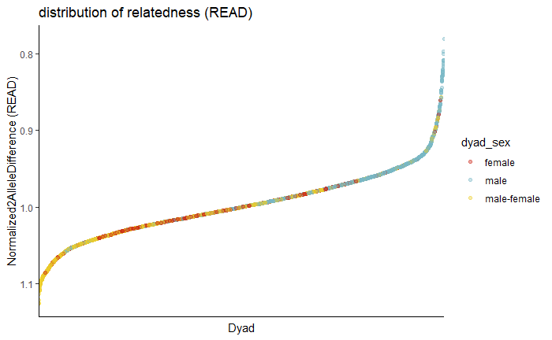

```r
#plot relatedness P0 (y-axis) for every dyad (x-axis), ordered from low to high relatedness and colored according to inter- or intragroup dyad

ggplot(READ_results_sample_info, aes(x = reorder(PairIndividuals, -Normalized2AlleleDifference), y = Normalized2AlleleDifference, color = dyad_sex))  +


  scale_colour_manual(values = three_colors, na.value = 1) +

  geom_point(alpha = 0.4, aes(y = Normalized2AlleleDifference)) + #plot relatedness estimates as points

  labs( x = "Dyad", y = "Normalized2AlleleDifference (READ)") +

  scale_y_continuous(trans = "reverse") + #flip y axis

  theme(axis.text.x = element_blank(), axis.ticks.x = element_blank()) +

  ggtitle("distribution of relatedness (READ)")
```

```r
NA
NA
```

Note: lower P0 values mean higher relatedness!

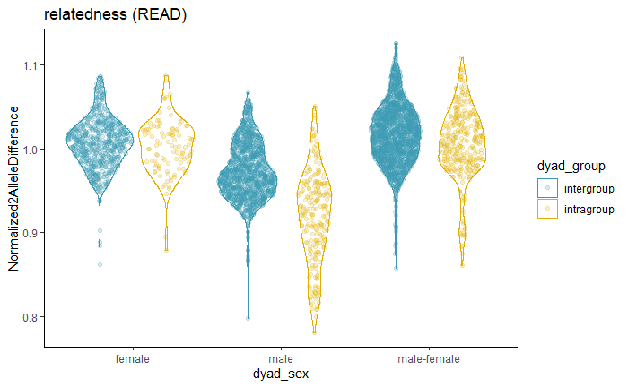

```r
#plot relatedness P0 (y-axis) for the different categories of sex of dyad (x-axis) colored according to group membership

ggplot(READ_results_sample_info, aes(x = dyad_sex, y = Normalized2AlleleDifference, color = dyad_group)) +

  geom_sina(alpha = 0.2) +

  geom_violin(alpha = 0) +

  scale_colour_manual(values = two_colors, na.value = 1) +

 ggtitle("relatedness (READ)")
```

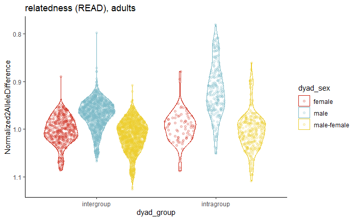

```r
#plot relatedness rab (y-axis) for the different categories of sex of dyad (x-axis) colored according to group membership

ggplot(filter(READ_results_sample_info, a_Group != "mpala_chicks", b_Group != "mpala_chicks"), aes(x = dyad_group, y = Normalized2AlleleDifference, color = dyad_sex)) +

  geom_sina(alpha = 0.2) +

  geom_violin(alpha = 0) +

  scale_y_continuous(trans = "reverse") +

  scale_colour_manual(values = three_colors, na.value = 1) +

 ggtitle("relatedness (READ), adults")
```

#### READ mapped to G. gallus

This is an assessment of the READ results produced by the Nextflow pipleine created by Ben Hume/SeqAna using the *G. gallus* genome. The data is saved in the folder `pipeline` in `Ref_Ggallus` as *meansP0_AncientDNA_normalized*. The preprocessed data (categorizes unrelated, first- and second-order related) is sotred as *READ_results*.

```r
READ_rawresults_gg <- read.delim("data/pipeline/Ref_Ggallus/meansP0_AncientDNA_normalized", header = TRUE, sep = " ", as.is = TRUE)
str(READ_rawresults_gg)
```

```
'data.frame':   4560 obs. of  5 variables:
 $ PairIndividuals            : chr  "RGID1_S10RGID1_S11" "RGID1_S10RGID1_S14" "RGID1_S10RGID1_S16" "RGID1_S10RGID1_S21" ...
 $ Normalized2AlleleDifference: num  0.984 0.959 0.973 0.968 0.98 ...
 $ StandardError              : num  0.00491 0.00558 0.00521 0.00496 0.00532 ...
 $ NonNormalizedP0            : num  0.346 0.338 0.343 0.341 0.345 ...
 $ NonNormalizedStandardError : num  0.00173 0.00196 0.00184 0.00174 0.00187 ...
```

```r
READ_kinresults_gg <- read.delim("data/pipeline/Ref_Ggallus/READ_results", header = TRUE, sep = "\t", as.is = TRUE)
str(READ_kinresults_gg)
```

```
'data.frame':   4560 obs. of  4 variables:
 $ PairIndividuals: chr  "RGID1_S10RGID1_S11" "RGID1_S10RGID1_S14" "RGID1_S10RGID1_S16" "RGID1_S10RGID1_S21" ...
 $ Relationship   : chr  "Unrelated" "Unrelated" "Unrelated" "Unrelated" ...
 $ Z_upper        : num  NA NA NA NA NA NA NA NA NA NA ...
 $ Z_lower        : num  -15.75 -9.53 -12.84 -12.53 -13.92 ...
```

Merge these two result files

```r
READ_results_gg <- left_join(READ_rawresults_gg, READ_kinresults_gg, by = "PairIndividuals")
str(READ_results_gg)
```

```
'data.frame':   4560 obs. of  8 variables:
 $ PairIndividuals            : chr  "RGID1_S10RGID1_S11" "RGID1_S10RGID1_S14" "RGID1_S10RGID1_S16" "RGID1_S10RGID1_S21" ...
 $ Normalized2AlleleDifference: num  0.984 0.959 0.973 0.968 0.98 ...
 $ StandardError              : num  0.00491 0.00558 0.00521 0.00496 0.00532 ...
 $ NonNormalizedP0            : num  0.346 0.338 0.343 0.341 0.345 ...
 $ NonNormalizedStandardError : num  0.00173 0.00196 0.00184 0.00174 0.00187 ...
 $ Relationship               : chr  "Unrelated" "Unrelated" "Unrelated" "Unrelated" ...
 $ Z_upper                    : num  NA NA NA NA NA NA NA NA NA NA ...
 $ Z_lower                    : num  -15.75 -9.53 -12.84 -12.53 -13.92 ...
```

Now we need to split the *PairIndividuals* into individual 1 and 2, identify these individuals and then create the dyads corresponding to the previous results.

```r
#Need to split PairIndividuals into 2 new columns
READ_results_gg$RGSM_a <- gsub("(RGID[[:alnum:]]{1}_S[[:alnum:]]{1,2})(RGID[[:alnum:]]{1}_S[[:alnum:]]{1,2})", "\\1", READ_results_gg$PairIndividuals)

READ_results_gg$RGSM_b <- gsub("(RGID[[:alnum:]]{1}_S[[:alnum:]]{1,2})(RGID[[:alnum:]]{1}_S[[:alnum:]]{1,2})", "\\2", READ_results_gg$PairIndividuals)

#create a new column that includes RGSM_dyad
READ_results_gg$RGSM_dyad <- if_else(READ_results_gg$RGSM_a < READ_results_gg$RGSM_b, paste(READ_results_gg$RGSM_a, READ_results_gg$RGSM_b, sep = "-"), paste(READ_results_gg$RGSM_b, READ_results_gg$RGSM_a, sep = "-"))

str(READ_results_gg)
```

```
'data.frame':   4560 obs. of  11 variables:
 $ PairIndividuals            : chr  "RGID1_S10RGID1_S11" "RGID1_S10RGID1_S14" "RGID1_S10RGID1_S16" "RGID1_S10RGID1_S21" ...
 $ Normalized2AlleleDifference: num  0.984 0.959 0.973 0.968 0.98 ...
 $ StandardError              : num  0.00491 0.00558 0.00521 0.00496 0.00532 ...
 $ NonNormalizedP0            : num  0.346 0.338 0.343 0.341 0.345 ...
 $ NonNormalizedStandardError : num  0.00173 0.00196 0.00184 0.00174 0.00187 ...
 $ Relationship               : chr  "Unrelated" "Unrelated" "Unrelated" "Unrelated" ...
 $ Z_upper                    : num  NA NA NA NA NA NA NA NA NA NA ...
 $ Z_lower                    : num  -15.75 -9.53 -12.84 -12.53 -13.92 ...
 $ RGSM_a                     : chr  "RGID1_S10" "RGID1_S10" "RGID1_S10" "RGID1_S10" ...
 $ RGSM_b                     : chr  "RGID1_S11" "RGID1_S14" "RGID1_S16" "RGID1_S21" ...
 $ RGSM_dyad                  : chr  "RGID1_S10-RGID1_S11" "RGID1_S10-RGID1_S14" "RGID1_S10-RGID1_S16" "RGID1_S10-RGID1_S21" ...
```

### Combined relatedness results

merge ngsrelate and lcmlkin

```r
relate_results <- full_join(ngsRelate_results_sample_info, lcmlkin_results_sample_info, by = "RGSM_dyad")
relate_results <- full_join(relate_results, READ_results_sample_info, by = "RGSM_dyad")
```

merge datasets mapped to G. gallus

```r
relate_results_gg <- full_join(ngsRelate_results_sample_info_gg, lcmlkin_results_ID_gg, by = "RGSM_dyad")
relate_results_gg <- full_join(relate_results_gg, READ_results_gg, by = "RGSM_dyad")
```

```r
#add breeding pair information



relate_results <- left_join(x = relate_results, y = pairs_ID, by = c("dyad" = "ID_Pair"))

filter(relate_results, breedingpair == "breeding_pair")
```

| a | b | RGSM_a.x | RGSM_b.x | nSites | J9 | J8 | J7 | J6 | J5 | J4 | J3 | J2 | J1 | rab | Fa | Fb | theta | inbred_relatedness_1_2 | inbred_relatedness_2_1 | fraternity | identity | zygosity | X2of3_IDB | F_diff_a_b | loglh | nIter | bestoptimll | coverage | X2dsfs | … |
| --- | --- | --- | --- | --- | --- | --- | --- | --- | --- | --- | --- | --- | --- | --- | --- | --- | --- | --- | --- | --- | --- | --- | --- | --- | --- | --- | --- | --- | --- | --- |
| 5 | 36 | RGID2_S15 | RGID2_S17 | 604150 | 0.882171 | 0.0e+00 | 0.056424 | 0.000000 | 0.000000 | 0.000002 | 0.000000 | 0.061402 | 0.000000 | 0.056424 | 0.061405 | 0.061403 | 0.028212 | 0.000000 | 0.000000 | 0.117826 | 0.000000 | 0.117827 | 0.117828 | 0.000001 | -977804.4 | 66 | -1 | 0.909756 | 2.937020e-01,1.279766e-01,4.611708e-02,1.104510e-01,1.864416e-01,4.492855e-02,4.822382e-02,5.759354e-02,8.456580e-02 | … |
| 7 | 15 | RGID1_S55 | RGID1_S75 | 456749 | 0.513996 | 9.0e-06 | 0.051943 | 0.000000 | 0.000000 | 0.338299 | 0.000000 | 0.095753 | 0.000000 | 0.051948 | 0.434052 | 0.095753 | 0.025974 | 0.000000 | 0.000000 | 0.147696 | 0.000000 | 0.147696 | 0.316850 | 0.169149 | -725571.8 | 70 | -1 | 0.687793 | 3.490331e-01,1.504103e-01,6.086985e-02,6.000802e-02,1.057497e-01,2.303098e-02,7.129890e-02,7.835659e-02,1.012426e-01 | … |
| 7 | 90 | RGID1_S55 | RGID2_S12 | 438737 | 0.526230 | 2.0e-06 | 0.052365 | 0.000000 | 0.000000 | 0.290977 | 0.000000 | 0.130426 | 0.000000 | 0.052366 | 0.421403 | 0.130426 | 0.026183 | 0.000000 | 0.000000 | 0.182791 | 0.000000 | 0.182791 | 0.328281 | 0.145488 | -706402.7 | 102 | -1 | 0.660670 | 3.446640e-01,1.466536e-01,6.681558e-02,5.951714e-02,1.080047e-01,2.589380e-02,7.218040e-02,7.145682e-02,1.048140e-01 | … |
| 18 | 24 | RGID1_S59 | RGID1_S62 | 472416 | 0.733049 | 0.0e+00 | 0.011792 | 0.005035 | 0.000001 | 0.000000 | 0.000000 | 0.250123 | 0.000000 | 0.011792 | 0.250123 | 0.255159 | 0.005896 | 0.000000 | 0.000000 | 0.261915 | 0.000000 | 0.261915 | 0.264433 | -0.002517 | -761924.7 | 114 | -1 | 0.711385 | 3.516980e-01,9.728303e-02,7.013525e-02,9.833019e-02,1.189474e-01,4.569653e-02,7.128208e-02,4.285563e-02,1.037719e-01 | … |
| 24 | 54 | RGID1_S62 | RGID1_S58 | 435662 | 0.663842 | 3.7e-05 | 0.020250 | 0.051826 | 0.000001 | 0.000000 | 0.000000 | 0.264045 | 0.000000 | 0.020269 | 0.264045 | 0.315872 | 0.010135 | 0.000000 | 0.000001 | 0.284294 | 0.000000 | 0.284295 | 0.310227 | -0.025913 | -702125.6 | 58 | -1 | 0.656039 | 3.602435e-01,8.205904e-02,7.582859e-02,1.061496e-01,1.107291e-01,4.934255e-02,7.307630e-02,3.614527e-02,1.064260e-01 | … |
| 36 | 45 | RGID2_S17 | RGID1_S63 | 562870 | 0.641603 | 0.0e+00 | 0.157864 | 0.164834 | 0.021921 | 0.000000 | 0.001508 | 0.012267 | 0.000003 | 0.175439 | 0.013778 | 0.199024 | 0.090649 | 0.000757 | 0.010963 | 0.170131 | 0.000003 | 0.170134 | 0.275980 | -0.082417 | -907415.8 | 198 | -1 | 0.847595 | 3.322281e-01,7.731769e-02,3.956675e-02,1.442751e-01,1.620221e-01,7.277878e-02,3.473767e-02,3.372721e-02,1.033465e-01 | … |
| 51 | 54 | RGID2_S16 | RGID1_S58 | 494875 | 0.587836 | 0.0e+00 | 0.054461 | 0.280241 | 0.000000 | 0.000000 | 0.000000 | 0.077461 | 0.000000 | 0.054461 | 0.077461 | 0.357702 | 0.027231 | 0.000000 | 0.000000 | 0.131923 | 0.000000 | 0.131923 | 0.272043 | -0.140121 | -790559.5 | 42 | -1 | 0.745205 | 3.349147e-01,6.632013e-02,6.613005e-02,1.509893e-01,1.222893e-01,7.493496e-02,5.881969e-02,2.681725e-02,9.878461e-02 | … |
| 51 | 66 | RGID2_S16 | RGID1_S65 | 507450 | 0.540131 | 0.0e+00 | 0.132211 | 0.252306 | 0.027992 | 0.000000 | 0.000640 | 0.041852 | 0.004868 | 0.158553 | 0.047359 | 0.327018 | 0.085289 | 0.005188 | 0.018864 | 0.174063 | 0.004868 | 0.178931 | 0.333716 | -0.126153 | -808046.6 | 70 | -1 | 0.764141 | 3.536211e-01,6.624967e-02,4.798508e-02,1.423115e-01,1.308324e-01,7.472101e-02,4.320715e-02,2.888345e-02,1.121888e-01 | … |
| 64 | 94 | RGID1_S44 | RGID1_S76 | 546911 | 0.786559 | 0.0e+00 | 0.021154 | 0.000140 | 0.002051 | 0.000000 | 0.000000 | 0.190094 | 0.000002 | 0.022694 | 0.190096 | 0.192287 | 0.011605 | 0.000002 | 0.001028 | 0.211248 | 0.000002 | 0.211250 | 0.213371 | -0.000070 | -882169.3 | 114 | -1 | 0.823563 | 3.422007e-01,1.050438e-01,6.032223e-02,1.053538e-01,1.290255e-01,4.833714e-02,6.132543e-02,4.761579e-02,1.007756e-01 | … |
| 84 | 90 | RGID1_S52 | RGID2_S12 | 478634 | 0.619593 | 1.0e-06 | 0.050609 | 0.000000 | 0.000000 | 0.187664 | 0.000000 | 0.142133 | 0.000000 | 0.050610 | 0.329797 | 0.142133 | 0.025305 | 0.000000 | 0.000000 | 0.192742 | 0.000000 | 0.192742 | 0.286575 | 0.093832 | -774486.8 | 130 | -1 | 0.720749 | 3.397338e-01,1.370854e-01,6.560448e-02,7.056886e-02,1.233482e-01,3.149224e-02,6.778295e-02,6.315288e-02,1.012312e-01 | … |

```r
NA
```

save full dataset

```r
save(relate_results, file = "data/relate_results.RData")
```

combine both mapping datasets

```r
relate_results_NmGg <- full_join(relate_results, relate_results_gg, by = "RGSM_dyad", suffix = c(".Nm", ".Gg"))
```

plot

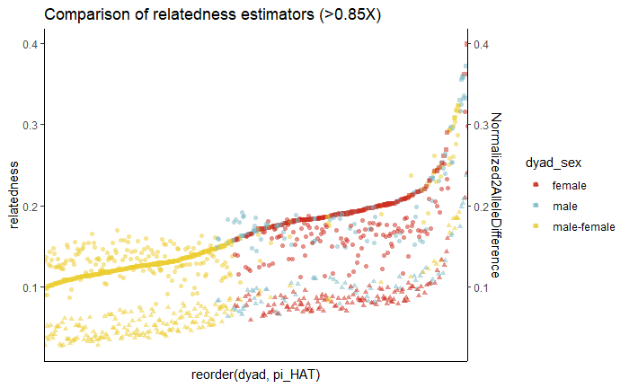

```r
theme_set(theme_classic())

#plot relatedness pi_HAT and rab (y-axis) for every dyad (x-axis), ordered from low to high relatedness and colored according to inter- or intragroup dyad

ggplot(filter(relate_results, coverage > 0.85), aes(x = reorder(dyad, pi_HAT), color = dyad_sex)) +

  scale_colour_manual(values = three_colors) +

  geom_point(alpha = 0.5, aes(y = pi_HAT), shape = 15) + #plot lcmlkin relatedness estimates as points

  geom_point(alpha = 0.5, aes(y = 1.2-Normalized2AlleleDifference), shape = 16) + #plot READ estimate

  geom_point(alpha = 0.5, aes(y = rab), shape = 17) + # plot ngsRelate estimates

  theme(axis.text.x = element_blank(), axis.ticks.x = element_blank()) +

  scale_y_continuous(

    name = "relatedness", #features of first axis

    sec.axis = sec_axis(~., name = "Normalized2AlleleDifference") #features of second axis
  ) +

  ggtitle("Comparison of relatedness estimators (>0.85X)")
```

```r
NA
NA
```